# Checking Burden Measures

Kendra Wyant

2020-09-11

### Notes

This script checks data from RISK participants’ burden reports by computing descriptives and checking for missingness and potential errors.

9/05/20 - updates to this check script include:  
- more descriptive variable names and removal of wristband/carrying phone data  
- recoding of one of the measures so that all scales are in same direction  
- numerous checks into missing data and number of participants and subsequent corrections/edits (see new Data Validity Checks section).

9/06/20 - updates to script include:  
- final time point descriptives section - histograms (final appraisal for each signal) and table of comments for dislike measures (why did they dislike it).  
- table with mean response for each signal.  
- plot mean response at each time point for each item.  
- table of mean response for each item at all 3 time points.

9/11/20 - updates to script include:  
- confirmed missing dates are start time from qualtrics.  
- renamed text vars to sms.  
- confirmed 139 UTCs and found extra UTC was for subid 138 (FU3), updated data log - more details in script.  
- final sample of participants who completed study = 132.

### Setup

Paths

```r
path_data <- "./database"
```

Packages

```r
library(tidyverse)
library(lmSupport)
library(janitor)
library(lubridate)
library(kableExtra)
library(psych)
library(rtf)
```

### Import Data and glimpse

Burden data

```r
burden <- read_rds(file.path(path_data, "burden.rds"))

burden <- burden %>%
  mutate(date_central = as_datetime(as.integer(utc),
                                    tz = 'America/Chicago')) %>%
  mutate(date_central = date(date_central)) %>%
  select(subid,
         utc,
         date_central,
         sleep_interfere = rbm_5,
         sleep_dislike = rbm_6,
         sleep_use_1year = rbm_7,
         sleep_text = rbm_8,
         daily_survey_interfere = rbm_9,
         daily_survey_dislike = rbm_10,
         daily_survey_complete4 = rbm_11,
         daily_survey_complete1 = rbm_12,
         daily_survey_text = rbm_13,
         voice_note_interfere = rbm_14,
         voice_note_dislike = rbm_15,
         voice_note_1year = rbm_16,
         voice_note_text = rbm_17,
         location_dislike = rbm_22,
         location_1year = rbm_23,
         location_text = rbm_24,
         sms_logs_dislike = rbm_25,
         sms_logs_1year = rbm_26,
         sms_content_dislike = rbm_27,
         sms_content_1year = rbm_28,
         phone_logs_dislike = rbm_29,
         phone_logs_1year = rbm_30,
         phone_text = rbm_31) %>%
  # recode scale to be consistent with other questions (dislike, interference)
  # All scales will now be measuring a negative attribute of the measure with 5
  # being the strongest negative view (strongly agree)
  mutate(across(c(sleep_use_1year,
                daily_survey_complete4,
                daily_survey_complete1,
                voice_note_1year,
                location_1year,
                sms_logs_1year,
                sms_content_1year,
                phone_logs_1year),
                ~recode(., "5" = "1", "4" = "2", "3" = "3", "2" = "4", "1" = "5"))) %>%
  glimpse()
```

```
## Rows: 428
## Columns: 26
## $ subid                  <chr> "001", "002", "003", "001", "002", "003",…
## $ utc                    <chr> "1490978317", "1492812248", "1493227629",…
## $ date_central           <date> 2017-03-31, 2017-04-21, 2017-04-26, 2017…
## $ sleep_interfere        <chr> "3", "1", "1", "2", "1", "1", "1", "1", "…
## $ sleep_dislike          <chr> "2", "1", "1", "2", "1", "1", "2", "1", "…
## $ sleep_use_1year        <chr> "2", "1", "1", "2", "1", "1", "1", "1", "…
## $ sleep_text             <chr> "I would like to know more about the bedd…
## $ daily_survey_interfere <chr> "2", "2", "1", "2", "2", "1", "2", "1", "…
## $ daily_survey_dislike   <chr> "2", "2", "1", "2", "3", "1", "2", "1", "…
## $ daily_survey_complete4 <chr> "2", "1", "1", "3", "1", "1", "2", "1", "…
## $ daily_survey_complete1 <chr> "2", "1", "1", "2", "1", "1", "1", "1", "…
## $ daily_survey_text      <chr> "The daily survey questions should be cha…
## $ voice_note_interfere   <chr> "2", "2", "1", "2", "1", "1", "2", "1", "…
## $ voice_note_dislike     <chr> "2", "2", "1", "2", "1", "2", "2", "3", "…
## $ voice_note_1year       <chr> "2", "1", "1", "2", "1", "1", "1", "2", "…
## $ voice_note_text        <chr> "I like being able to voice my feelings i…
## $ location_dislike       <chr> "2", "2", "1", "3", "1", "1", "1", "1", "…
## $ location_1year         <chr> "2", "1", "1", "3", "1", "1", "1", "1", "…
## $ location_text          <chr> "No problems with having my locations mon…
## $ sms_logs_dislike       <chr> "2", "3", "1", "3", "1", "1", "1", "2", "…
## $ sms_logs_1year         <chr> "2", "1", "1", "2", "1", "1", "1", "3", "…
## $ sms_content_dislike    <chr> "2", "3", "1", "3", "1", "1", "4", "2", "…
## $ sms_content_1year      <chr> "2", "1", "1", "2", "1", "1", "4", "1", "…
## $ phone_logs_dislike     <chr> "2", "3", "1", "3", "1", "1", "1", "2", "…
## $ phone_logs_1year       <chr> "2", "1", "1", "3", "1", "1", "1", "1", "…
## $ phone_text             <chr> "No issues with the iPhone.", "Again I ha…
```

155 participants contribute to a total of 428 reports. The earliest recorded report is from 2017-03-31 and the most recent is from 2019-12-05.

### Data Validity Checks

Missing (NA) values

```r
if(any(is.na(burden))){
  missing <- burden %>%
    summarise(across(everything(), ~sum(is.na(.)))) %>%
    gather(key = "var", value = "num_NA" ) %>%
    filter(num_NA > 0)
  missing %>%
    kable(caption = "Variables with missing values",
          table.attr = "style='width:40%;'") %>%
    kable_styling(position = "left",
                  bootstrap_options = c("striped", "condensed"))
}else {
  paste("No missing values")
}
```

Variables with missing values

| var | num_NA |
| --- | --- |
| utc | 2 |
| date_central | 2 |
| sleep_interfere | 197 |
| sleep_dislike | 197 |
| sleep_use_1year | 197 |
| sleep_text | 200 |
| daily_survey_interfere | 3 |
| daily_survey_dislike | 3 |
| daily_survey_complete4 | 3 |
| daily_survey_complete1 | 3 |
| daily_survey_text | 3 |
| voice_note_interfere | 3 |
| voice_note_dislike | 3 |
| voice_note_1year | 3 |
| voice_note_text | 3 |
| location_dislike | 3 |
| location_1year | 3 |
| location_text | 5 |
| sms_logs_dislike | 3 |
| sms_logs_1year | 3 |
| sms_content_dislike | 3 |
| sms_content_1year | 3 |
| phone_logs_dislike | 3 |
| phone_logs_1year | 3 |
| phone_text | 4 |

There are 855 missing values (NA) from 25 unique variables in the entire dataset.

Not all participants were given sleep monitors which explains why there are so many missing values (n_NA = 197).

Three surveys are blank and appear to be in error.

```r
burden %>%
  filter_at(vars(daily_survey_interfere:daily_survey_text), any_vars(is.na(.))) %>%
  kable(caption = "Missing values (blank surveys)") %>%
  kable_styling(bootstrap_options = c("striped", "condensed")) %>%
  scroll_box(width = "100%", height = "170px")
```

Missing values (blank surveys)

| subid | utc | date_central | sleep_interfere | sleep_dislike | sleep_use_1year | sleep_text | daily_survey_interfere | daily_survey_dislike | daily_survey_complete4 | daily_survey_complete1 | daily_survey_text | voice_note_interfere | voice_note_dislike | voice_note_1year | voice_note_text | location_dislike | location_1year | location_text | sms_logs_dislike | sms_logs_1year | sms_content_dislike | sms_content_1year | phone_logs_dislike | phone_logs_1year | phone_text |
| --- | --- | --- | --- | --- | --- | --- | --- | --- | --- | --- | --- | --- | --- | --- | --- | --- | --- | --- | --- | --- | --- | --- | --- | --- | --- |
| 007 | 1505491356 | 2017-09-15 | NA | NA | NA | NA | NA | NA | NA | NA | NA | NA | NA | NA | NA | NA | NA | NA | NA | NA | NA | NA | NA | NA | NA |
| 042 | 1524606662 | 2018-04-24 | NA | NA | NA | NA | NA | NA | NA | NA | NA | NA | NA | NA | NA | NA | NA | NA | NA | NA | NA | NA | NA | NA | NA |
| 237 | 1564087833 | 2019-07-25 | NA | NA | NA | NA | NA | NA | NA | NA | NA | NA | NA | NA | NA | NA | NA | NA | NA | NA | NA | NA | NA | NA | NA |

subid 007

```r
burden %>%
  filter(subid == "007") %>%
  kable(caption = "subid 007") %>%
  kable_styling(bootstrap_options = c("striped", "condensed")) %>%
  row_spec(3, color = "red") %>%
  scroll_box(width = "100%", height = "450px")
```

subid 007

| subid | utc | date_central | sleep_interfere | sleep_dislike | sleep_use_1year | sleep_text | daily_survey_interfere | daily_survey_dislike | daily_survey_complete4 | daily_survey_complete1 | daily_survey_text | voice_note_interfere | voice_note_dislike | voice_note_1year | voice_note_text | location_dislike | location_1year | location_text | sms_logs_dislike | sms_logs_1year | sms_content_dislike | sms_content_1year | phone_logs_dislike | phone_logs_1year | phone_text |
| --- | --- | --- | --- | --- | --- | --- | --- | --- | --- | --- | --- | --- | --- | --- | --- | --- | --- | --- | --- | --- | --- | --- | --- | --- | --- |
| 007 | 1500307989 | 2017-07-17 | 1 | 1 | 1 | Heart rate isn’t always measurable if I sleep with a pillow between me and the bed which can produce missed readings. | 1 | 1 | 1 | 1 | These are inobtrusive. No negatives. | 1 | 3 | 2 | Often feel I’m repeating myself. Occasionally unable to respond cuz of mixed company. | 1 | 1 | I found it interesting. I’ll probably use it after the study to track my steps. | 2 | 3 | 2 | 1 | 2 | 1 | No strong feelings on this. If it helped it’d be width the intrusion. |
| 007 | 1503074974 | 2017-08-18 | 1 | 1 | 1 | No problems, and the data is neat too. | 1 | 1 | 1 | 1 | Good check in. | 1 | 3 | 1 | I’m never sure what to say and the timing sometimes doesn’t work. | 1 | 1 | Step tracking is a bonus. | 1 | 1 | 1 | 1 | 1 | 1 | Sadly most of my commas are over Facebook. |
| 007 | 1505491356 | 2017-09-15 | NA | NA | NA | NA | NA | NA | NA | NA | NA | NA | NA | NA | NA | NA | NA | NA | NA | NA | NA | NA | NA | NA | NA |
| 007 | 1507735769 | 2017-10-11 | 1 | 1 | 1 | Often loses the heartbeat. | 1 | 1 | 1 | 1 | Relatively Unobtrusive | 1 | 1 | 1 | Inobtrusive. | 1 | 1 | going to be using this afterwards. | 1 | 1 | 1 | 1 | 1 | 1 | Unobtrusive |

Study dates from visits file confirm surveys completed on 07-17, 08-18, and 10-11 are accurate. Will remove survey from 9-15.

subid 042

```r
burden %>%
  filter(subid == "042") %>%
  kable(caption = "subid 042") %>%
  kable_styling(bootstrap_options = c("striped", "condensed")) %>%
  row_spec(1, color = "red") %>%
  scroll_box(width = "100%", height = "400px")
```

subid 042

| subid | utc | date_central | sleep_interfere | sleep_dislike | sleep_use_1year | sleep_text | daily_survey_interfere | daily_survey_dislike | daily_survey_complete4 | daily_survey_complete1 | daily_survey_text | voice_note_interfere | voice_note_dislike | voice_note_1year | voice_note_text | location_dislike | location_1year | location_text | sms_logs_dislike | sms_logs_1year | sms_content_dislike | sms_content_1year | phone_logs_dislike | phone_logs_1year | phone_text |
| --- | --- | --- | --- | --- | --- | --- | --- | --- | --- | --- | --- | --- | --- | --- | --- | --- | --- | --- | --- | --- | --- | --- | --- | --- | --- |
| 042 | 1524606662 | 2018-04-24 | NA | NA | NA | NA | NA | NA | NA | NA | NA | NA | NA | NA | NA | NA | NA | NA | NA | NA | NA | NA | NA | NA | NA |
| 042 | 1525986817 | 2018-05-10 | 1 | 1 | 1 | I like it. I like seeing my score and how my behaviors influence it, it makes me try harder to sleep well | 1 | 2 | 3 | 2 | I am very neutral about them, I don’t mind them, but I don’t look forward to them | 2 | 2 | 3 | I like doing them, I just have to get in the habit of doing it at the same time so I won’t forget | 1 | 3 | I really don’t even think about it | 1 | 3 | 2 | 3 | 2 | 3 | Again, it doesn’t even occur to me to be concerned about it, I’m boring, I know! |
| 042 | 1528487642 | 2018-06-08 | 1 | 1 | 2 | I liked it. I enjoyed getting my sleep score in the morning. I liked the alarm feature. It made me want to get better rest. | 2 | 2 | 2 | 1 | Surveys were not a problem, sometimes cumbersome, but usually welcome. And quick, easy to keep up with | 2 | 2 | 2 | They were fine when i remembered to respond. | 2 | 2 | I never even thought about it. | 2 | 2 | 2 | 2 | 2 | 2 | Again, i don’t even think about itðŸ˜€ |

According to notes file, participant was incorrectly given intake at followup 1 so is missing burden measure for followup 1.

KW: Will NOT remove per discussion with John. Reasoning = they completed the study.

subid 237

```r
burden %>%
  filter(subid == "237")  %>%
  kable(caption = "subid 237") %>%
  kable_styling(bootstrap_options = c("striped", "condensed")) %>%
  row_spec(1, color = "red") %>%
  scroll_box(width = "100%", height = "150px")
```

subid 237

| subid | utc | date_central | sleep_interfere | sleep_dislike | sleep_use_1year | sleep_text | daily_survey_interfere | daily_survey_dislike | daily_survey_complete4 | daily_survey_complete1 | daily_survey_text | voice_note_interfere | voice_note_dislike | voice_note_1year | voice_note_text | location_dislike | location_1year | location_text | sms_logs_dislike | sms_logs_1year | sms_content_dislike | sms_content_1year | phone_logs_dislike | phone_logs_1year | phone_text |
| --- | --- | --- | --- | --- | --- | --- | --- | --- | --- | --- | --- | --- | --- | --- | --- | --- | --- | --- | --- | --- | --- | --- | --- | --- | --- |
| 237 | 1564087833 | 2019-07-25 | NA | NA | NA | NA | NA | NA | NA | NA | NA | NA | NA | NA | NA | NA | NA | NA | NA | NA | NA | NA | NA | NA | NA |

According to notes file, participant withdrew from study at followup1 before data was collected. Will remove survey from dataframe.

Missing dates

```r
burden %>%
  filter(is.na(date_central)) %>%
  kable() %>%
  kable_styling(bootstrap_options = c("striped", "condensed")) %>%
  column_spec(2, color = "red") %>%
  scroll_box(width = "100%", height = "400px")
```

| subid | utc | date_central | sleep_interfere | sleep_dislike | sleep_use_1year | sleep_text | daily_survey_interfere | daily_survey_dislike | daily_survey_complete4 | daily_survey_complete1 | daily_survey_text | voice_note_interfere | voice_note_dislike | voice_note_1year | voice_note_text | location_dislike | location_1year | location_text | sms_logs_dislike | sms_logs_1year | sms_content_dislike | sms_content_1year | phone_logs_dislike | phone_logs_1year | phone_text |
| --- | --- | --- | --- | --- | --- | --- | --- | --- | --- | --- | --- | --- | --- | --- | --- | --- | --- | --- | --- | --- | --- | --- | --- | --- | --- |
| 033 | NA | NA | 1 | 1 | 1 | Family members were sick this last month, so we slept in different locations, it was not a priority at the time to move the sleep monitor to other sleeping locations | 2 | 2 | 4 | 2 | At times i experience guilt if i miss a survey. | 5 | 5 | 5 | I discontinued this very early on as it caused a lot of frustration | 1 | 1 | This is not an issues | 2 | 2 | 2 | 2 | 2 | 2 | This is not an issue |
| 208 | NA | NA | NA | NA | NA | NA | 1 | 1 | 1 | 1 | None | 2 | 2 | 2 | The voice message seems useless | 1 | 1 | None | 1 | 1 | 1 | 1 | 1 | 1 | None |

subid 033

```r
burden %>%
  filter(subid == "033") %>%
  kable(caption = "subid 033") %>%
  kable_styling(bootstrap_options = c("striped", "condensed")) %>%
  row_spec(2, color = "red") %>%
  scroll_box(width = "100%", height = "600px")
```

subid 033

| subid | utc | date_central | sleep_interfere | sleep_dislike | sleep_use_1year | sleep_text | daily_survey_interfere | daily_survey_dislike | daily_survey_complete4 | daily_survey_complete1 | daily_survey_text | voice_note_interfere | voice_note_dislike | voice_note_1year | voice_note_text | location_dislike | location_1year | location_text | sms_logs_dislike | sms_logs_1year | sms_content_dislike | sms_content_1year | phone_logs_dislike | phone_logs_1year | phone_text |
| --- | --- | --- | --- | --- | --- | --- | --- | --- | --- | --- | --- | --- | --- | --- | --- | --- | --- | --- | --- | --- | --- | --- | --- | --- | --- |
| 033 | 1515684753 | 2018-01-11 | 1 | 1 | 1 | Use of the sleep monitor is very simple. No issues. I find the results interesting and informative. | 2 | 2 | 3 | 1 | Completing the surveys was fairly simple. I did find myself however feeling guilty and upset with myself when I missed one. Sometimes the surveys come at inconvient times like when I am at work,drivin… | 5 | 5 | 5 | This was very stressful for me and I completely stopped even trying. I could not get the message to be longer than 10 seconds the majority of the time. Sometimes I tried 8 times in one day without suc… | 1 | 1 | Not an issue at all | 1 | 2 | 2 | 2 | 1 | 2 | Neutral. I don’t really have anything to hide I don’t mind this information being collected |
| 033 | NA | NA | 1 | 1 | 1 | Family members were sick this last month, so we slept in different locations, it was not a priority at the time to move the sleep monitor to other sleeping locations | 2 | 2 | 4 | 2 | At times i experience guilt if i miss a survey. | 5 | 5 | 5 | I discontinued this very early on as it caused a lot of frustration | 1 | 1 | This is not an issues | 2 | 2 | 2 | 2 | 2 | 2 | This is not an issue |
| 033 | 1521125112 | 2018-03-15 | 1 | 1 | 5 | Using the sleep monitor was not an issue at all. Very simple to use and set up. I will likely purchase this monitor to continue using now that the study is complete. Every one in awhile i would have t… | 3 | 2 | 4 | 1 | At times it was difficult to complete every survey as i was at work, busy with the kids, etc. I found myself feeling guilty when i missed and this caused some stress. | 5 | 5 | 5 | I experienced issues with this from the very beginning and discontinued early on. I was unable to get the message beyond 8-10 seconds with close to 6 attempts each day. Was not worth the time or stres… | 1 | 5 | I had no issues with my location being tracked | 1 | 1 | 1 | 1 | 1 | 1 | This was not an issue. I had no concerns or stress about this,. |

Missing date for followup 2 - should be 2018-02-20 according to visit dates. Will correct. (From notes -> FU2 is missing UTC. Calculated from start time as 1519142940)

subid 208

```r
burden %>%
  filter(subid == "208") %>%
  kable(caption = "subid 208") %>%
  kable_styling(bootstrap_options = c("striped", "condensed")) %>%
  row_spec(2, color = "red") %>%
  scroll_box(width = "100%", height = "250px")
```

subid 208

| subid | utc | date_central | sleep_interfere | sleep_dislike | sleep_use_1year | sleep_text | daily_survey_interfere | daily_survey_dislike | daily_survey_complete4 | daily_survey_complete1 | daily_survey_text | voice_note_interfere | voice_note_dislike | voice_note_1year | voice_note_text | location_dislike | location_1year | location_text | sms_logs_dislike | sms_logs_1year | sms_content_dislike | sms_content_1year | phone_logs_dislike | phone_logs_1year | phone_text |
| --- | --- | --- | --- | --- | --- | --- | --- | --- | --- | --- | --- | --- | --- | --- | --- | --- | --- | --- | --- | --- | --- | --- | --- | --- | --- |
| 208 | 1555624414 | 2019-04-18 | NA | NA | NA | NA | 2 | 1 | 3 | 2 | Four seemed too many | 2 | 2 | 2 | It was ok | 1 | 2 | Doesn’t bother me | 2 | 2 | 2 | 3 | 2 | 3 | It’s ok |
| 208 | NA | NA | NA | NA | NA | NA | 1 | 1 | 1 | 1 | None | 2 | 2 | 2 | The voice message seems useless | 1 | 1 | None | 1 | 1 | 1 | 1 | 1 | 1 | None |
| 208 | 1561489654 | 2019-06-25 | NA | NA | NA | NA | 2 | 2 | 2 | 2 | It was a good check in for my emotions | 2 | 2 | 2 | Same | 1 | 1 | It didnâ€™t bother me | 2 | 2 | 2 | 2 | 2 | 2 | It was fine |

Missing date for followup 2 - should be 2019-05-23 according to visit dates. Will correct. (From notes -> missing UTC, correct value = 1558648860).

Updated dataframe

```r
burden <- burden %>%
  # filter out 2 blank/false surveys
  filter(subid != "237") %>%
  filter(!(subid == "007" & date_central == "2017-09-15")) %>%
  # add dates to 2 missing followup2 visits
  mutate(date_central = case_when(subid == "033" & is.na(date_central) ~ "2018-02-20",
                                  subid == "208" & is.na(date_central) ~ "2019-05-23",
                                  TRUE ~ as.character(date_central))) %>%
  mutate(date_central = as_date(date_central)) %>%
  glimpse()
```

```
## Rows: 426
## Columns: 26
## $ subid                  <chr> "001", "002", "003", "001", "002", "003",…
## $ utc                    <chr> "1490978317", "1492812248", "1493227629",…
## $ date_central           <date> 2017-03-31, 2017-04-21, 2017-04-26, 2017…
## $ sleep_interfere        <chr> "3", "1", "1", "2", "1", "1", "1", "1", "…
## $ sleep_dislike          <chr> "2", "1", "1", "2", "1", "1", "2", "1", "…
## $ sleep_use_1year        <chr> "2", "1", "1", "2", "1", "1", "1", "1", "…
## $ sleep_text             <chr> "I would like to know more about the bedd…
## $ daily_survey_interfere <chr> "2", "2", "1", "2", "2", "1", "2", "1", "…
## $ daily_survey_dislike   <chr> "2", "2", "1", "2", "3", "1", "2", "1", "…
## $ daily_survey_complete4 <chr> "2", "1", "1", "3", "1", "1", "2", "1", "…
## $ daily_survey_complete1 <chr> "2", "1", "1", "2", "1", "1", "1", "1", "…
## $ daily_survey_text      <chr> "The daily survey questions should be cha…
## $ voice_note_interfere   <chr> "2", "2", "1", "2", "1", "1", "2", "1", "…
## $ voice_note_dislike     <chr> "2", "2", "1", "2", "1", "2", "2", "3", "…
## $ voice_note_1year       <chr> "2", "1", "1", "2", "1", "1", "1", "2", "…
## $ voice_note_text        <chr> "I like being able to voice my feelings i…
## $ location_dislike       <chr> "2", "2", "1", "3", "1", "1", "1", "1", "…
## $ location_1year         <chr> "2", "1", "1", "3", "1", "1", "1", "1", "…
## $ location_text          <chr> "No problems with having my locations mon…
## $ sms_logs_dislike       <chr> "2", "3", "1", "3", "1", "1", "1", "2", "…
## $ sms_logs_1year         <chr> "2", "1", "1", "2", "1", "1", "1", "3", "…
## $ sms_content_dislike    <chr> "2", "3", "1", "3", "1", "1", "4", "2", "…
## $ sms_content_1year      <chr> "2", "1", "1", "2", "1", "1", "4", "1", "…
## $ phone_logs_dislike     <chr> "2", "3", "1", "3", "1", "1", "1", "2", "…
## $ phone_logs_1year       <chr> "2", "1", "1", "3", "1", "1", "1", "1", "…
## $ phone_text             <chr> "No issues with the iPhone.", "Again I ha…
```

Now there is a total of 154 participants contributing to a total of 426 observations.

Read in subids from rawdata folder to confirm correct number of participants

```r
# df of subids from raw_data folder
subids_rawdata <- enframe(list.files(file.path("./raw_data"))) %>%
  mutate(subid = as.numeric(value)) %>%
  filter(!is.na(subid)) %>%
  mutate(subid = str_pad(value, 3, "left", "0")) %>%
  select(subid) %>%
  mutate(subid = as.character(subid)) %>%
  arrange(subid)

# df of subids from burden survey
subids_burden <- enframe(burden$subid) %>%
  select(subid = value) %>%
  distinct(subid, .keep_all = FALSE) %>%
  arrange(subid)

# compare dfs
if (identical(subids_rawdata, subids_burden)) {
  paste("Both dataframes are identical")
}else {
  paste("The dataframes do not match")
}
```

```
## [1] "Both dataframes are identical"
```

There are 154 subids listed in the raw data folder.  
There are 154 unique subids in the burden data.  
A close inspection of the two lists confirm these lists of subids are identical.

Num surveys per subid

```r
burden_4 <- burden %>%
  group_by(subid) %>%
  summarise(n_obs = n()) %>%
  filter(n_obs > 3)

burden_4 %>%
  kable(caption = "Subids with more than 3 observations",
          table.attr = "style='width:40%;'") %>%
  kable_styling(position = "left",
                  bootstrap_options = c("striped", "condensed"))
```

Subids with more than 3 observations

| subid | n_obs |
| --- | --- |
| 139 | 4 |

1 participant took the burden survey four times.

subid 139

```r
burden %>%
  filter(subid == "139") %>%
  kable(caption = "subid 139") %>%
  kable_styling(bootstrap_options = c("striped", "condensed")) %>%
  row_spec(2:3, color = "red") %>%
  scroll_box(width = "100%", height = "500px")
```

subid 139

| subid | utc | date_central | sleep_interfere | sleep_dislike | sleep_use_1year | sleep_text | daily_survey_interfere | daily_survey_dislike | daily_survey_complete4 | daily_survey_complete1 | daily_survey_text | voice_note_interfere | voice_note_dislike | voice_note_1year | voice_note_text | location_dislike | location_1year | location_text | sms_logs_dislike | sms_logs_1year | sms_content_dislike | sms_content_1year | phone_logs_dislike | phone_logs_1year | phone_text |
| --- | --- | --- | --- | --- | --- | --- | --- | --- | --- | --- | --- | --- | --- | --- | --- | --- | --- | --- | --- | --- | --- | --- | --- | --- | --- |
| 139 | 1542640179 | 2018-11-19 | 3 | 3 | 3 | Not using it | 3 | 3 | 1 | 1 | The surveys re enforce not drinking | 3 | 3 | 1 | Helps me not drink | 1 | 1 | I don’t think about it | 1 | 1 | 1 | 1 | 1 | 1 | Doesn’t bother me |
| 139 | 1546960308 | 2019-01-08 | 3 | 3 | 3 | Not using | 2 | 1 | 1 | 1 | enforcing. My soberity | 1 | 1 | 5 | Enforcing my sobriety | 1 | 5 | I don’t care if I’m being tracked | 1 | 5 | 1 | 5 | 1 | 5 | I don’t call or text anyone of importance |
| 139 | 1546974043 | 2019-01-08 | 1 | 2 | 3 | It was fun data to look at each morning. A bit of routine work to keep in place though | 2 | 2 | 4 | 2 | It was a good tool to help me reflect. However, when i was busy or travelling it felt a bit more like a chore. Especially during the last weeks | 2 | 2 | 3 | It was good to think about how i was feeling each day, but also became a bit of a to do | 2 | 3 | I support voluntary data tracking for science | 2 | 3 | 3 | 3 | 2 | 3 | This is becoming a bit more personal , but seems like valuable info |
| 139 | 1548168774 | 2019-01-22 | NA | NA | NA | NA | 2 | 2 | 1 | 1 | Good, helped me not drink. | 2 | 3 | 1 | Good , helped. Me not drink | 1 | 1 | I did,, care if someone tracks me | 1 | 1 | 1 | 1 | 1 | 1 | I did, t care |

subid has two completed surveys on 01-08 with different answers. Cannot find notes on why this is. Will not affect analyses on most recent time point, but will not be able to use in analyses across time.

KW: 9/11/20 Closer inspection of visit_dates rds and other original sources reveal that utc 1546974043 for subid 139 should be changed to subid 138. This was subid 138’s final visit so it was the only data collected which may be why this error has not yet been caught.

correct subid on utc 1546974043

```r
burden <- burden %>%
  mutate(subid = case_when(subid == "139" & utc == "1546974043" ~ "138",
                           TRUE ~ subid))

# check
burden %>%
  filter(subid == "139") %>%
  select(1:3)
```

```
## # A tibble: 3 x 3
##   subid utc        date_central
##   <chr> <chr>      <date>
## 1 139   1542640179 2018-11-19
## 2 139   1546960308 2019-01-08
## 3 139   1548168774 2019-01-22
```

```r
burden %>%
  filter(subid == "138") %>%
  select(1:3)
```

```
## # A tibble: 3 x 3
##   subid utc        date_central
##   <chr> <chr>      <date>
## 1 138   1541095779 2018-11-01
## 2 138   1543955223 2018-12-04
## 3 138   1546974043 2019-01-08
```

```r
burden_3 <- burden %>%
  group_by(subid) %>%
  summarise(n_obs = n()) %>%
  filter(n_obs == 3)

burden_2 <- burden %>%
  group_by(subid) %>%
  summarise(n_obs = n()) %>%
  filter(n_obs == 2)

burden_2 %>%
  kable(caption = "Subids with 2 observations",
          table.attr = "style='width:40%;'") %>%
  kable_styling(position = "left",
                  bootstrap_options = c("striped", "condensed"))
```

Subids with 2 observations

| subid | n_obs |
| --- | --- |
| 053 | 2 |
| 076 | 2 |
| 078 | 2 |
| 085 | 2 |
| 092 | 2 |
| 104 | 2 |
| 212 | 2 |
| 243 | 2 |

```r
burden_1 <- burden %>%
  group_by(subid) %>%
  summarise(n_obs = n()) %>%
  filter(n_obs == 1)

burden_1 %>%
  kable(caption = "Subids with 1 observation",
          table.attr = "style='width:40%;'") %>%
  kable_styling(position = "left",
                  bootstrap_options = c("striped", "condensed"))
```

Subids with 1 observation

| subid | n_obs |
| --- | --- |
| 029 | 1 |
| 047 | 1 |
| 059 | 1 |
| 082 | 1 |
| 093 | 1 |
| 116 | 1 |
| 172 | 1 |
| 200 | 1 |
| 205 | 1 |
| 209 | 1 |
| 218 | 1 |
| 221 | 1 |
| 232 | 1 |
| 265 | 1 |

132 participants took the burden survey three times.  
8 participants took the burden survey two times.  
14 participants took the burden survey one time.

### Final Time Point Descriptives

Create df of final time points

```r
# pull out most recent survey for each subid
burden_final <- burden %>%
  group_by(subid) %>%
  arrange(desc(date_central)) %>%
  slice(1) %>%
  glimpse()
```

```
## Rows: 154
## Columns: 26
## Groups: subid [154]
## $ subid                  <chr> "001", "002", "003", "005", "006", "007",…
## $ utc                    <chr> "1496678162", "1497649340", "1498071783",…
## $ date_central           <date> 2017-06-05, 2017-06-16, 2017-06-21, 2017…
## $ sleep_interfere        <chr> "2", "1", "1", "2", "2", "1", "5", "1", "…
## $ sleep_dislike          <chr> "2", "1", "1", "2", "4", "1", "1", "1", "…
## $ sleep_use_1year        <chr> "2", "5", "1", "2", "2", "1", "4", "1", "…
## $ sleep_text             <chr> "There were problems with the sleep monit…
## $ daily_survey_interfere <chr> "2", "2", "2", "2", "2", "1", "3", "1", "…
## $ daily_survey_dislike   <chr> "2", "2", "1", "2", "2", "1", "2", "1", "…
## $ daily_survey_complete4 <chr> "2", "5", "1", "2", "2", "1", "4", "1", "…
## $ daily_survey_complete1 <chr> "2", "5", "1", "2", "1", "1", "3", "1", "…
## $ daily_survey_text      <chr> "The home surveys were easy to complete b…
## $ voice_note_interfere   <chr> "2", "1", "2", "2", "2", "1", "2", "1", "…
## $ voice_note_dislike     <chr> "2", "1", "1", "2", "2", "1", "2", "1", "…
## $ voice_note_1year       <chr> "2", "1", "1", "2", "2", "1", "2", "1", "…
## $ voice_note_text        <chr> "I enjoyed the daily check more than all …
## $ location_dislike       <chr> "2", "2", "1", "4", "2", "1", "2", "1", "…
## $ location_1year         <chr> "2", "1", "1", "2", "1", "1", "3", "1", "…
## $ location_text          <chr> "Not an issue.", "This didn't change wher…
## $ sms_logs_dislike       <chr> "2", "2", "1", "2", "2", "1", "2", "1", "…
## $ sms_logs_1year         <chr> "2", "1", "2", "2", "1", "1", "3", "1", "…
## $ sms_content_dislike    <chr> "2", "2", "1", "4", "2", "1", "3", "1", "…
## $ sms_content_1year      <chr> "2", "1", "2", "2", "1", "1", "3", "1", "…
## $ phone_logs_dislike     <chr> "4", "2", "1", "2", "2", "1", "3", "1", "…
## $ phone_logs_1year       <chr> "2", "1", "2", "2", "1", "1", "3", "1", "…
## $ phone_text             <chr> "I did not use the texting options and pr…
```

#### Sleep Monitor

Sleep monitor burden measures (rbm_5 - rbm_7)

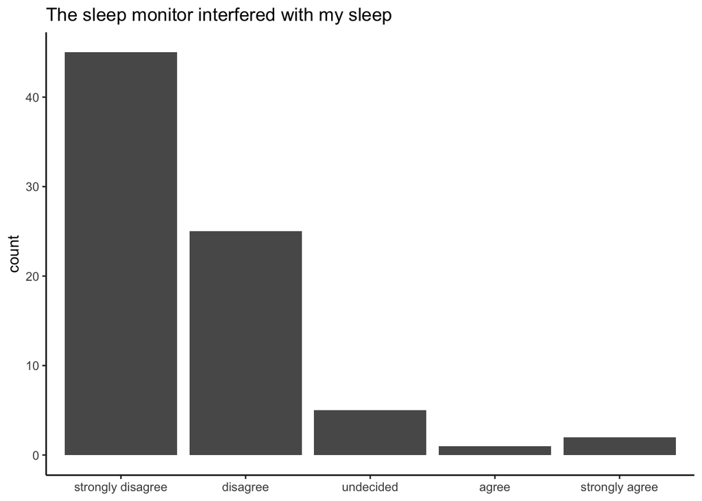

```r
burden_final %>%
  mutate(interference = recode(sleep_interfere,
                               "1" = "strongly disagree",
                               "2" = "disagree",
                               "3" = "undecided",
                               "4" = "agree",
                               "5" = "strongly agree")) %>%
  mutate(interference = fct_relevel(factor(interference,
                                           c("strongly disagree",
                                             "disagree",
                                             "undecided",
                                             "agree",
                                             "strongly agree")))) %>%
  drop_na(interference) %>%
  ggplot(aes (x = interference)) +
  geom_bar() +
  scale_x_discrete(drop = FALSE) +
  xlab(NULL) +
  ggtitle("The sleep monitor interfered with my sleep") +
  theme_classic()
```

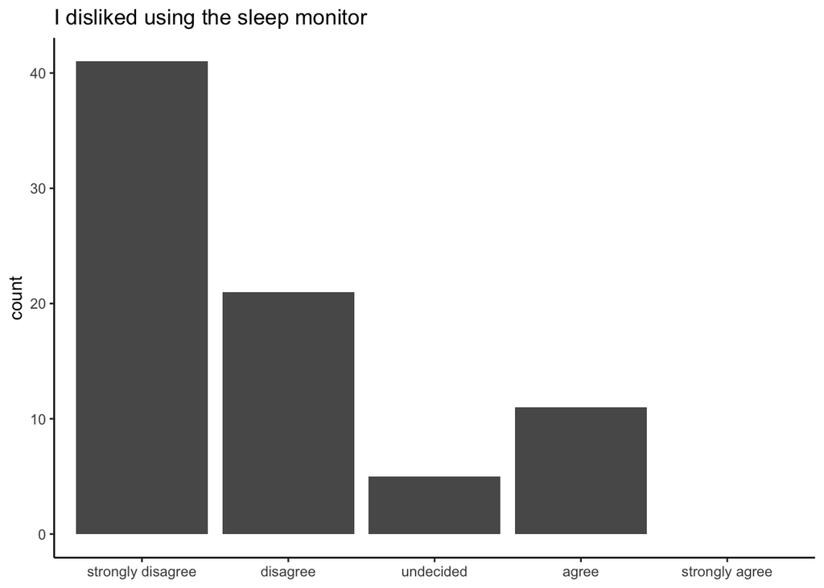

```r
burden_final %>%
  mutate(dislike = recode(sleep_dislike,
                          "1" = "strongly disagree",
                          "2" = "disagree",
                          "3" = "undecided",
                          "4" = "agree",
                          "5" = "strongly agree")) %>%
  mutate(dislike = fct_relevel(factor(dislike,
                                      c("strongly disagree",
                                        "disagree",
                                        "undecided",
                                        "agree",
                                        "strongly agree")))) %>%
  drop_na(dislike) %>%
  ggplot(aes (x = dislike)) +
  geom_bar() +
  scale_x_discrete(drop = FALSE) +
  xlab(NULL) +
  ggtitle("I disliked using the sleep monitor") +
  theme_classic()
```

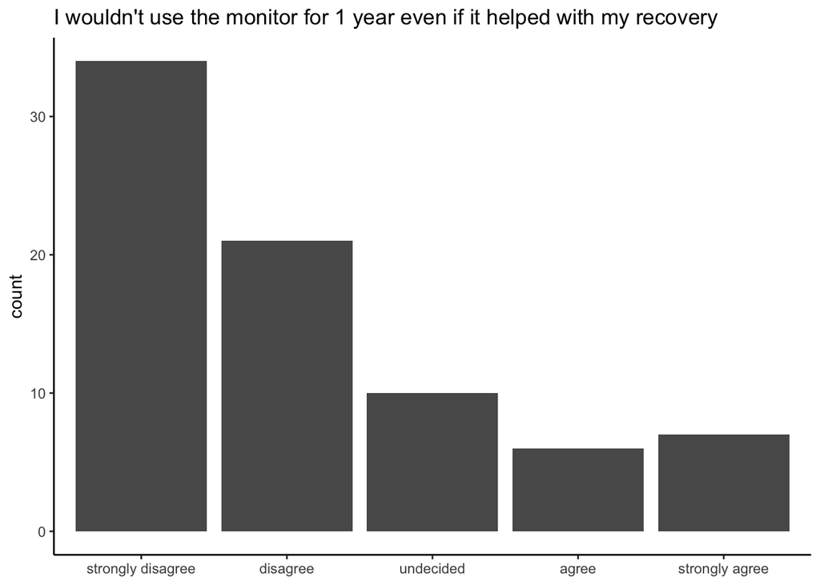

```r
burden_final %>%
  mutate(willing = recode(sleep_use_1year,
                          "1" = "strongly disagree",
                          "2" = "disagree",
                          "3" = "undecided",
                          "4" = "agree",
                          "5" = "strongly agree")) %>%
  mutate(willing = fct_relevel(factor(willing,
                                      c("strongly disagree",
                                        "disagree",
                                        "undecided",
                                        "agree",
                                        "strongly agree")))) %>%
  drop_na(willing) %>%
  ggplot(aes (x = willing)) +
  geom_bar() +
  scale_x_discrete(drop = FALSE) +
  xlab(NULL) +
  ggtitle("I wouldn't use the monitor for 1 year even if it helped with my recovery") +
  theme_classic()
```

Text comments on why people dislike the sleep monitor

```r
burden_final %>%
  filter(sleep_dislike >= 4) %>%
  select(subid, sleep_text) %>%
  kable(caption =
        "Comments from participants who disliked the sleep monitor (agree/strongly agree)") %>%
  kable_styling() %>%
  kable_styling(bootstrap_options = c("striped", "condensed"))
```

Comments from participants who disliked the sleep monitor (agree/strongly agree)

| subid | sleep_text |
| --- | --- |
| 006 | No issues with it, only had a few nights when the readings seemed real innacurate. My biggest issues were just fears that I would crinkle it irreperably while sleeping on top of it or during transport… |
| 011 | I wish I used it with my iPad because Bluetooth killa my batteries and I use my phone as an alarm. |
| 028 | It was difficult to use the monitor as I was transitioning between multiple locations. |
| 034 | It didn’t seem to work reliably for me, so I think that was the biggest cause of my reluctance to use it/spend time (albeit only a few seconds) adjusting the monitor strip to be properly under me |
| 043 | Relatively innocuous device, but I travel a lot |
| 056 | Would have to wake up to use. |
| 080 | Just irritating. |
| 085 | I take a lot of naps, which significantly interferes with its accuracy. |
| 086 | Usually I would just forget to turn it on |
| 104 | I liked the insight |
| 119 | T ’s interesting |

Re: whether participants disliked the sleep monitor -  
0 participants said they strongly agree.  
11 participants said they agree.

From examining the text comments on the sleep monitor it seems people have an overall positive view of the monitor and many people enjoy being able to see their sleep data.

#### Daily Surveys

Daily survey burden measures (rbm_9 - rbm_12)

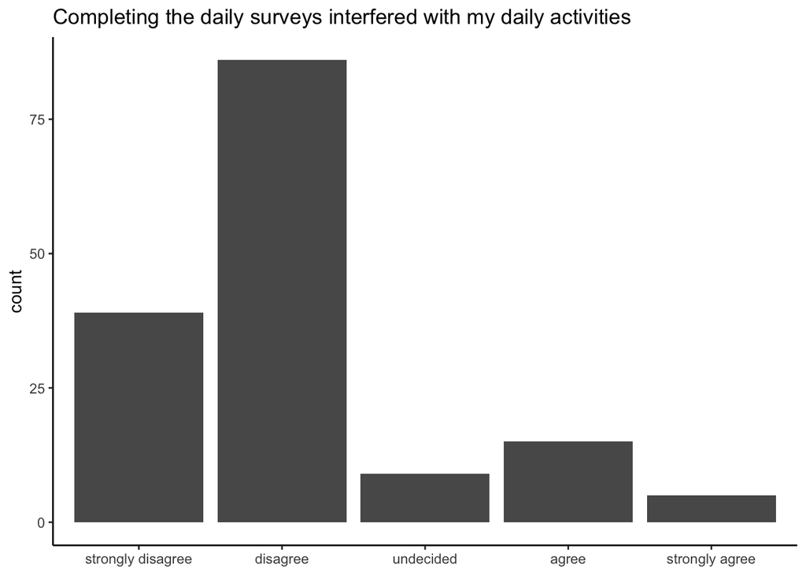

```r
burden_final %>%
  mutate(interference = recode(daily_survey_interfere,
                               "1" = "strongly disagree",
                               "2" = "disagree",
                               "3" = "undecided",
                               "4" = "agree",
                               "5" = "strongly agree")) %>%
  mutate(interference = fct_relevel(factor(interference,
                                           c("strongly disagree",
                                             "disagree",
                                             "undecided",
                                             "agree",
                                             "strongly agree")))) %>%
  drop_na(interference) %>%
  ggplot(aes (x = interference)) +
  geom_bar() +
  scale_x_discrete(drop = FALSE) +
  xlab(NULL) +
  ggtitle("Completing the daily surveys interfered with my daily activities") +
  theme_classic()
```

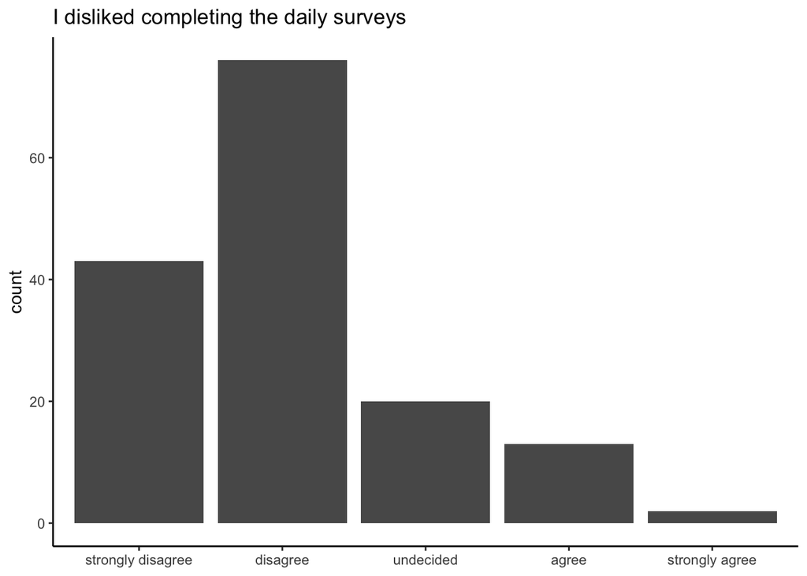

```r
burden_final %>%
  mutate(dislike = recode(daily_survey_dislike,
                          "1" = "strongly disagree",
                          "2" = "disagree",
                          "3" = "undecided",
                          "4" = "agree",
                          "5" = "strongly agree")) %>%
  mutate(dislike = fct_relevel(factor(dislike,
                                      c("strongly disagree",
                                        "disagree",
                                        "undecided",
                                        "agree",
                                        "strongly agree")))) %>%
  drop_na(dislike) %>%
  ggplot(aes (x = dislike)) +
  geom_bar() +
  scale_x_discrete(drop = FALSE) +
  xlab(NULL) +
  ggtitle("I disliked completing the daily surveys") +
  theme_classic()
```

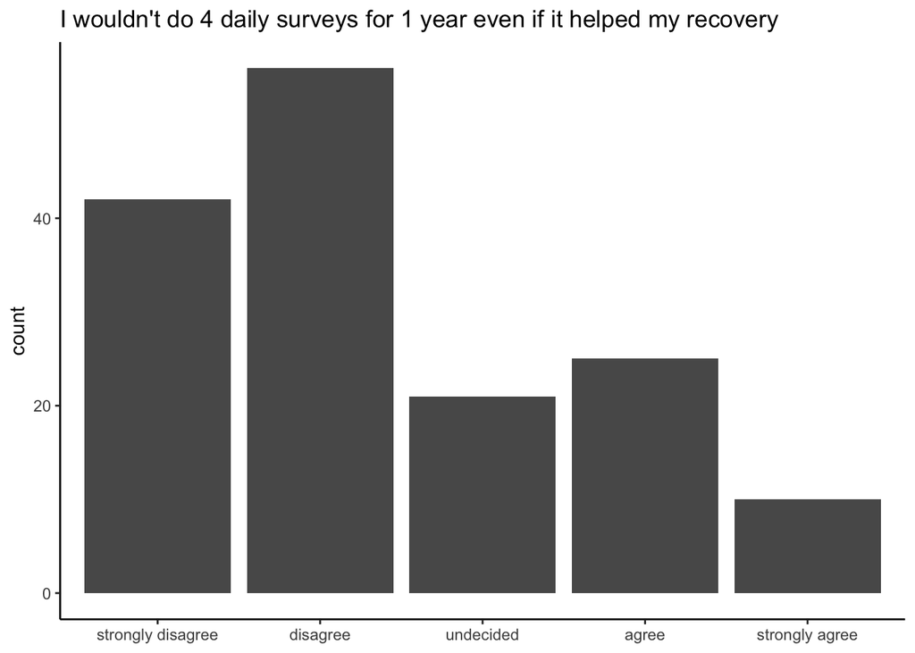

```r
burden_final %>%
  mutate(willing = recode(daily_survey_complete4,
                          "1" = "strongly disagree",
                          "2" = "disagree",
                          "3" = "undecided",
                          "4" = "agree",
                          "5" = "strongly agree")) %>%
  mutate(willing = fct_relevel(factor(willing,
                                      c("strongly disagree",
                                        "disagree",
                                        "undecided",
                                        "agree",
                                        "strongly agree")))) %>%
  drop_na(willing) %>%
  ggplot(aes (x = willing)) +
  geom_bar() +
  scale_x_discrete(drop = FALSE) +
  xlab(NULL) +
  ggtitle("I wouldn't do 4 daily surveys for 1 year even if it helped my recovery") +
  theme_classic()
```

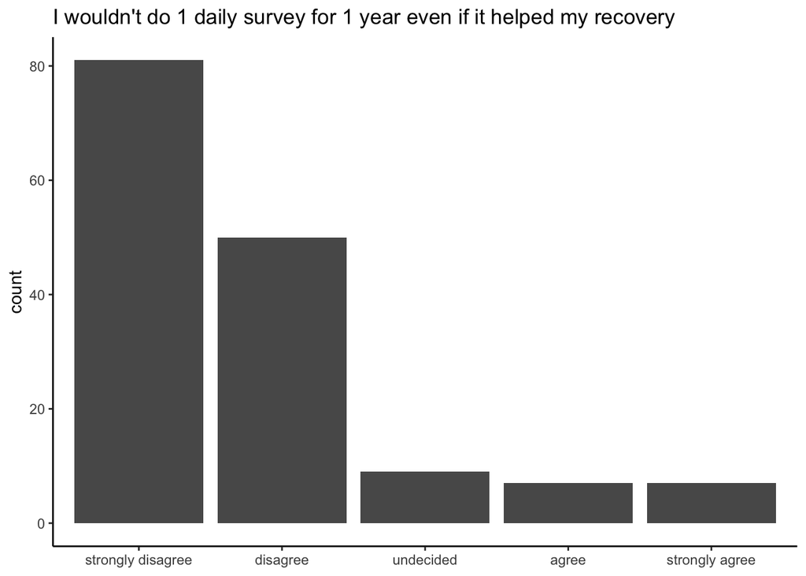

```r
burden_final %>%
  mutate(willing = recode(daily_survey_complete1,
                          "1" = "strongly disagree",
                          "2" = "disagree",
                          "3" = "undecided",
                          "4" = "agree",
                          "5" = "strongly agree")) %>%
  mutate(willing = fct_relevel(factor(willing,
                                      c("strongly disagree",
                                        "disagree",
                                        "undecided",
                                        "agree",
                                        "strongly agree")))) %>%
  drop_na(willing) %>%
  ggplot(aes (x = willing)) +
  geom_bar() +
  scale_x_discrete(drop = FALSE) +
  xlab(NULL) +
  ggtitle("I wouldn't do 1 daily survey for 1 year even if it helped my recovery") +
  theme_classic()
```

Text comments on why people dislike the daily surveys

```r
burden_final %>%
  filter(daily_survey_dislike >= 4) %>%
  select(subid, daily_survey_text) %>%
  kable(caption =
        "Comments from participants who disliked the daily surveys (agree/strongly agree)") %>%
  kable_styling(bootstrap_options = c("striped", "condensed"))
```

Comments from participants who disliked the daily surveys (agree/strongly agree)

| subid | daily_survey_text |
| --- | --- |
| 021 | I did well with my recovery on my own and the surveys were more of a burden at the end. Maybe base the number of surveys on each individual’s recovery progress. |
| 044 | It’s just annoying if I’m out hiking all day or if I’m out at night because I don’t like to be on my phone at all in those situations. |
| 054 | The four interruptions are rather a pain. I have wanted to yell -well NO i had not thought about drinking but now that YOU mentioned it I want a drink!!- |
| 056 | Hard to stop what your doing at work to be on your phone. Does not look good at work. |
| 074 | They were fine just sometimes bad timing |
| 076 | The surveys needs to evolve or be adjusted to my needs as an addict in treatment. \The questions repettwisty nature makes me feel as if my recovery is stuck in neutral. \The questions the user needs t… |
| 085 | My state cannot be measured so simply, for example I am often aroused (don’t mean sexually) and tired at the same time, but they are at opposite ends of your spectrum. |
| 103 | One daily would be great |
| 149 | Once i began drinking i had an aversion to the surveys |
| 188 | Just too many. |
| 204 | None |
| 222 | There were times it did interfere with daily activities or i wud get a reminder even and still forget to do it, but the reminders for the daily survey helped a lot |
| 223 | They kept me present |
| 232 | I felt it was an annoyance, another thing i had to do on top of everything else when it was so frequent. I found one per day is tolerable by days end not a set time. I am just too scattered with how m… |
| 259 | They were a hassle |

Re: whether participants disliked the daily surveys -  
2 participants said they strongly agree.  
13 participants said they agree.

Themes from text comments:

1. 3 surveys a day should be max - 4 is too many.
- A large proportion of texts mentioned 4 daily surveys as being too many - words used include: hassle, burdensome, irritating, annoying, overwhelming, pain, hate.
- Still, the surveys in isolation do not appear to be a problem (straight forward, simple, easy) and some even seem to enjoy them. It is the multiple surveys a day that begin to be a burden.
2. The daily surveys are a good length (short).
3. Other smaller issues include tech issues, expiring links, and being disrupted while at work.

#### Voice Note Messaging

Daily voice note check-in burden measures (rbm_14 - rbm_16)

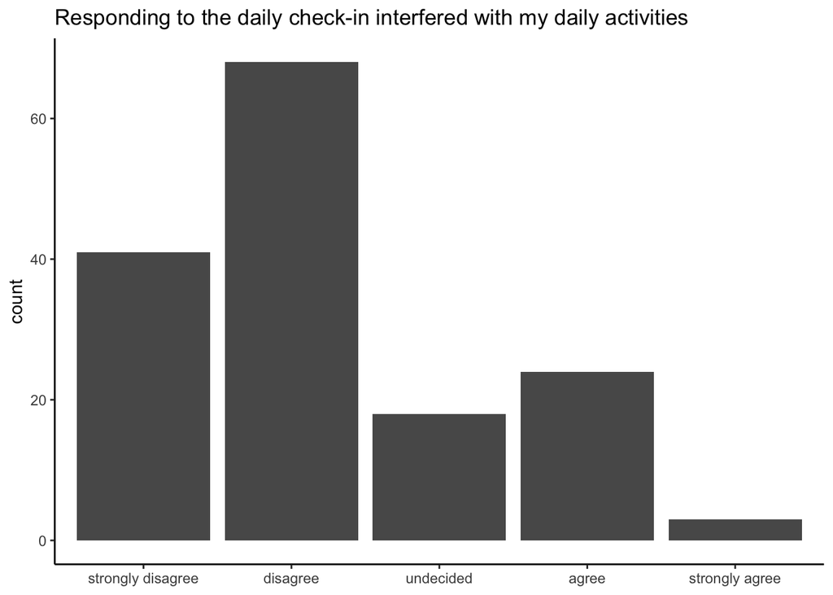

```r
burden_final %>%
  mutate(interference = recode(voice_note_interfere,
                               "1" = "strongly disagree",
                               "2" = "disagree",
                               "3" = "undecided",
                               "4" = "agree",
                               "5" = "strongly agree")) %>%
  mutate(interference = fct_relevel(factor(interference,
                                           c("strongly disagree",
                                             "disagree",
                                             "undecided",
                                             "agree",
                                             "strongly agree")))) %>%
  drop_na(interference) %>%
  ggplot(aes (x = interference)) +
  geom_bar() +
  scale_x_discrete(drop = FALSE) +
  xlab(NULL) +
  ggtitle("Responding to the daily check-in interfered with my daily activities") +
  theme_classic()
```

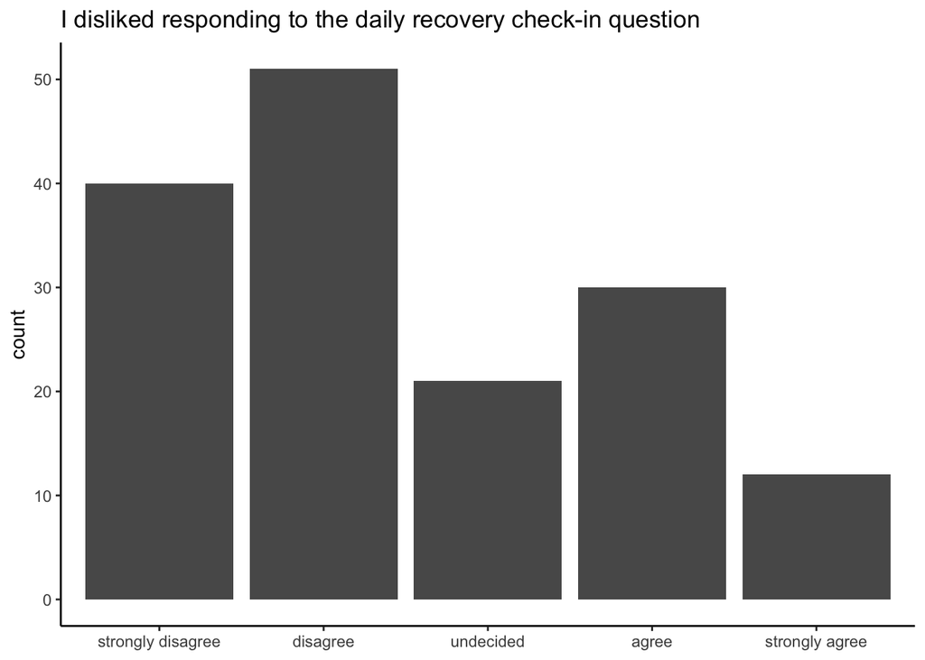

```r
burden_final %>%
  mutate(dislike = recode(voice_note_dislike,
                          "1" = "strongly disagree",
                          "2" = "disagree",
                          "3" = "undecided",
                          "4" = "agree",
                          "5" = "strongly agree")) %>%
  mutate(dislike = fct_relevel(factor(dislike,
                                      c("strongly disagree",
                                        "disagree",
                                        "undecided",
                                        "agree",
                                        "strongly agree")))) %>%
  drop_na(dislike) %>%
  ggplot(aes (x = dislike)) +
  geom_bar() +
  scale_x_discrete(drop = FALSE) +
  xlab(NULL) +
  ggtitle("I disliked responding to the daily recovery check-in question") +
  theme_classic()
```

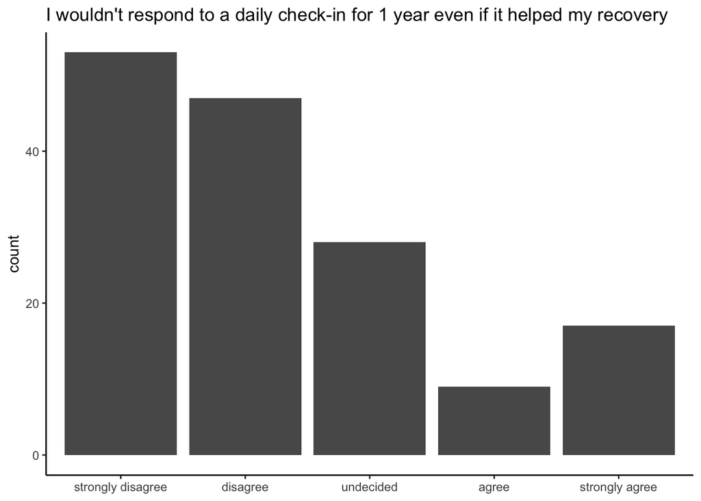

```r
burden_final %>%
  mutate(willing = recode(voice_note_1year,
                          "1" = "strongly disagree",
                          "2" = "disagree",
                          "3" = "undecided",
                          "4" = "agree",
                          "5" = "strongly agree")) %>%
  mutate(willing = fct_relevel(factor(willing,
                                      c("strongly disagree",
                                        "disagree",
                                        "undecided",
                                        "agree",
                                        "strongly agree")))) %>%
  drop_na(willing) %>%
  ggplot(aes (x = willing)) +
  geom_bar() +
  scale_x_discrete(drop = FALSE) +
  xlab(NULL) +
  ggtitle("I wouldn't respond to a daily check-in for 1 year even if it helped my recovery") +
  theme_classic()
```

Text comments on why people dislike the voice note check ins

```r
burden_final %>%
  filter(voice_note_dislike >= 4) %>%
  select(subid, voice_note_text) %>%
  kable(caption =
        "Comments from participants who disliked the voice check ins (agree/strongly agree)") %>%
  kable_styling(bootstrap_options = "striped", "condensed") %>%
  scroll_box(width = "100%", height = "600px")
```

Comments from participants who disliked the voice check ins (agree/strongly agree)

| subid | voice_note_text |
| --- | --- |
| 015 | I found the audio messages most challenging. |
| 018 | The audio portion was terrible. It takes time out of your day where you have to completely switch locations just so you can do t in private. I don’t like that people could hear me and the topic wherev… |
| 019 | Maybe right before bed, but hated it |
| 021 | Got to be a burden as the study progressed. |
| 027 | I am not much of a phone talker, so, I sometimes found it difficult to find words |
| 033 | I experienced issues with this from the very beginning and discontinued early on. I was unable to get the message beyond 8-10 seconds with close to 6 attempts each day. Was not worth the time or stres… |
| 034 | I often couldn’t think of anything to say, so I would have found a less open-ended prompt useful |
| 038 | Hard to find private time |
| 043 | Generally mildly negative |
| 056 | Not a good look to be on your phone at work |
| 066 | Positive |
| 076 | I quit the call in when the online surveys became to grating bro complete. |
| 078 | I never know what to say for the audio question. |
| 080 | Kind of weird. If one had sonnet bf specific to talk about , it would be much better |
| 085 | I hate the audio check in! |
| 092 | Oftentimes found myself in public places. Hard to record and if I did it was hard to open up |
| 121 | I did not do this part. I am not a fan of talking on/to a phone |
| 149 | Again, didn’t want to do it while drinking |
| 158 | Was annoying at times but not so annoying that I didn’t do it |
| 167 | Different |
| 172 | Sometimes forget to do them or fall asleep too early |
| 183 | These were annoying |
| 188 | I think that just this one survey would be beneficial |
| 193 | Quasi-redundant with questions. |
| 196 | I could never get into the routine of the audio check-in, it felt uncomfortable to me. |
| 201 | I just never really knew exactly what to say |
| 204 | None |
| 209 | I dislike the audio check in |
| 214 | I felt like I needed to seek out a private spot to do the audio message. I would have much preferred to type the message. |
| 221 | I just could never remember if I’d done them and there’s no way to see if you sent it. |
| 222 | The daily recovery check in voice msging made me feel really uncomfortable |
| 223 | I found it hard to talk to a me home about what i was feeling |
| 224 | This was the most difficult part of the study for me. I eventually just stopped completing the audio journal because I just didn’t have anything to say. It started to feel forced and unnatural |
| 232 | I may not want to always mentally realize how often i feel bad |
| 241 | Audio surveys were uncomfortable especially if there was no privacy to do them. They exemplified feelings of failure, defeat, and hopelessness for being able to achieve or maintain abstinence. |
| 243 | I found it hard to stay motivated to do it. |
| 245 | If I didn’t do it right away, I’d always forget about it. I also have to keep privacy in mind, since it’s not something I’d like to complete within earshot of others. |
| 248 | Easy to forget about if i didn’t complete right away in the morning |
| 255 | This one was harder to like because I felt like I needed privacy to complete it, which sometimes I don’t have. |
| 259 | I didn’t mind the voice record as much |
| 262 | Generally disliked the open ended nature of these. Maybe provide a rotating prompt? |
| 268 | Still hated these. Perhaps i would have liked it better if I had prompts to respond to. |

Re: whether participants disliked the voice notes -  
12 participants said they strongly agree.  
30 participants said they agree.

#### Phone Saving Location Information (GPS)

Location tracking burden measures (rbm_22 - rbm_23)

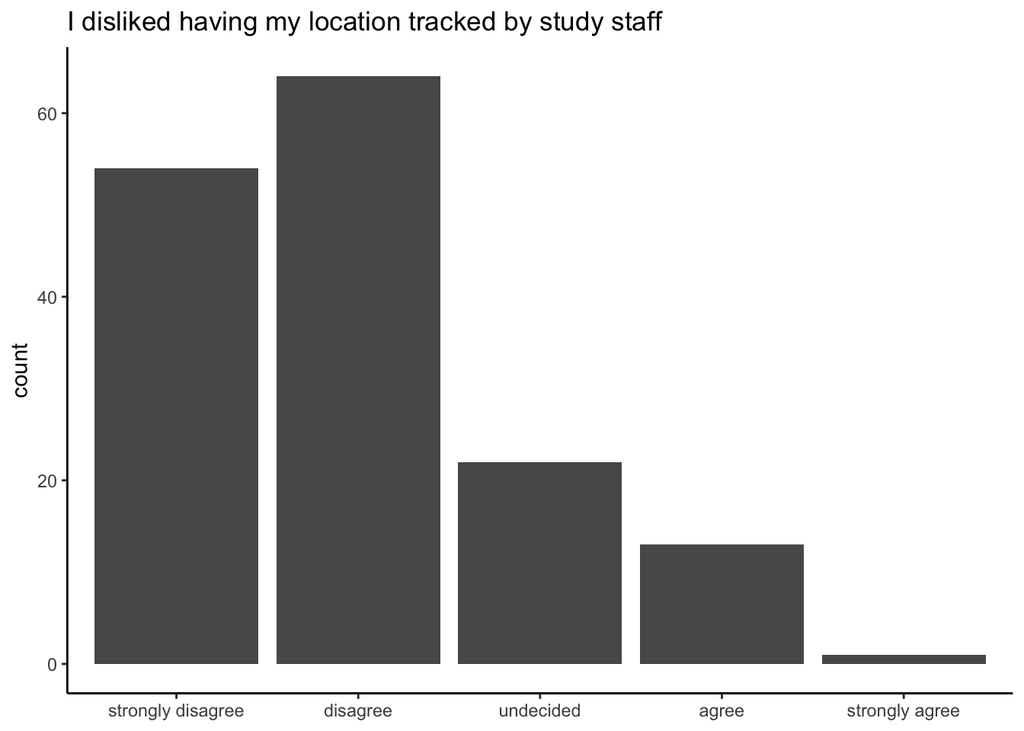

```r
burden_final %>%
  mutate(dislike = recode(location_dislike,
                          "1" = "strongly disagree",
                          "2" = "disagree",
                          "3" = "undecided",
                          "4" = "agree",
                          "5" = "strongly agree")) %>%
  mutate(dislike = fct_relevel(factor(dislike,
                                      c("strongly disagree",
                                        "disagree",
                                        "undecided",
                                        "agree",
                                        "strongly agree")))) %>%
  drop_na(dislike) %>%
  ggplot(aes (x = dislike)) +
  geom_bar() +
  scale_x_discrete(drop = FALSE) +
  xlab(NULL) +
  ggtitle("I disliked having my location tracked by study staff") +
  theme_classic()
```

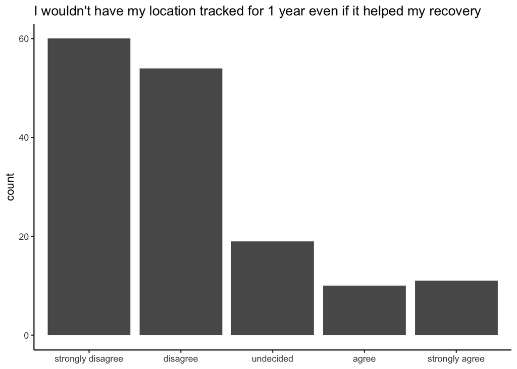

```r
burden_final %>%
  mutate(willing = recode(location_1year,
                          "1" = "strongly disagree",
                          "2" = "disagree",
                          "3" = "undecided",
                          "4" = "agree",
                          "5" = "strongly agree")) %>%
  mutate(willing = fct_relevel(factor(willing,
                                      c("strongly disagree",
                                        "disagree",
                                        "undecided",
                                        "agree",
                                        "strongly agree")))) %>%
  drop_na(willing) %>%
  ggplot(aes (x = willing)) +
  geom_bar() +
  scale_x_discrete(drop = FALSE) +
  xlab(NULL) +
  ggtitle("I wouldn't have my location tracked for 1 year even if it helped my recovery") +
  theme_classic()
```

Text comments on why people dislike the location tracking

```r
burden_final %>%
  filter(location_dislike >= 4) %>%
  select(subid, location_text) %>%
  kable(caption =
        "Comments from participants who disliked location tracking (agree/strongly agree)") %>%
  kable_styling(bootstrap_options = "striped", "condensed")
```

Comments from participants who disliked location tracking (agree/strongly agree)

| subid | location_text |
| --- | --- |
| 005 | Not a problme, I have nothing to hide! Held me accountable for my actikns |
| 043 | Big data |
| 066 | Positive |
| 085 | I would never allow this “in real life.” |
| 109 | No comment |
| 121 | It would be easy to just leave it at home if I wanted to go to a bar, etc |
| 167 | Not fond of being tracked |
| 181 | I’m a somewhat typical introverted, slightly paranoid, grump, so the idea of being tracked is automatically negative. That being said, if it’s something that helps people that can be a really good thi… |
| 196 | I am concerned with data privacy, and felt uncomfortable having my location actively tracked. |
| 203 | Same, i don’t feel comfortable with thebtracking |
| 232 | Feel weird about it because of today’s times in our government. Just saying, feel like liberties are stripped away a lot so hard to trust anyone. |
| 252 | Highly personal but if it helps okay |
| 259 | If it helps me then I would do it |
| 263 | Didn’t mind |

Re: whether participants disliked their location being tracked -  
1 participant said they strongly agree.  
13 participants said they agree.

The majority of participants do not mind their location being tracked. Often people forget it is being recorded or never think about it. A few people did mention that they did not like it - creepy, invasion of privacy, would not allow in “real life”, etc.

#### Phone Saving SMS and Call Log Information

##### SMS logs

sms logs burden measures (rbm_25 - rbm_26)

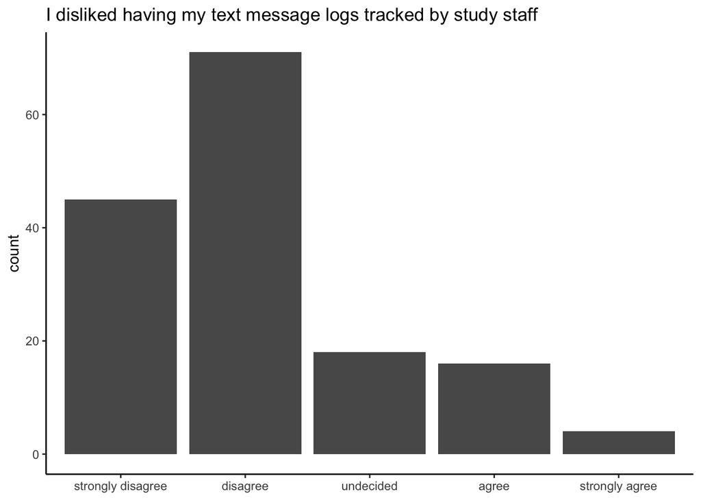

```r
burden_final %>%
  mutate(dislike = recode(sms_logs_dislike,
                          "1" = "strongly disagree",
                          "2" = "disagree",
                          "3" = "undecided",
                          "4" = "agree",
                          "5" = "strongly agree")) %>%
  mutate(dislike = fct_relevel(factor(dislike,
                                      c("strongly disagree",
                                        "disagree",
                                        "undecided",
                                        "agree",
                                        "strongly agree")))) %>%
  drop_na(dislike) %>%
  ggplot(aes (x = dislike)) +
  geom_bar() +
  scale_x_discrete(drop = FALSE) +
  xlab(NULL) +
  ggtitle("I disliked having my text message logs tracked by study staff") +
  theme_classic()
```

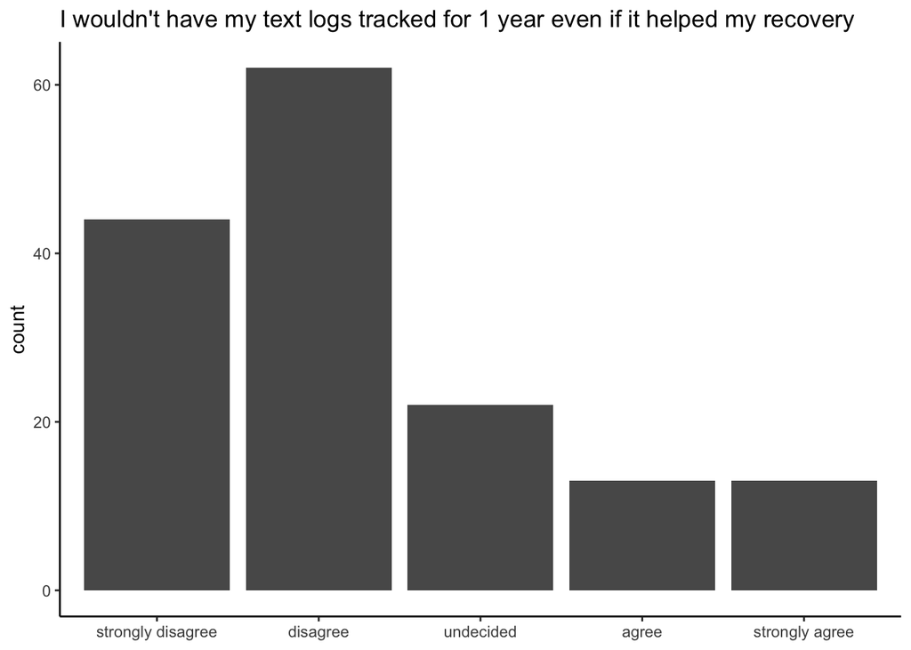

```r
burden_final %>%
  mutate(willing = recode(sms_logs_1year,
                          "1" = "strongly disagree",
                          "2" = "disagree",
                          "3" = "undecided",
                          "4" = "agree",
                          "5" = "strongly agree")) %>%
  mutate(willing = fct_relevel(factor(willing,
                                      c("strongly disagree",
                                        "disagree",
                                        "undecided",
                                        "agree",
                                        "strongly agree")))) %>%
  drop_na(willing) %>%
  ggplot(aes (x = willing)) +
  geom_bar() +
  scale_x_discrete(drop = FALSE) +
  xlab(NULL) +
  ggtitle("I wouldn't have my text logs tracked for 1 year even if it helped my recovery") +
  theme_classic()
```

Re: dislike of sms logs being collected  
4 participants said they strongly agree.  
16 participants said they agree.

##### SMS content

sms content burden measures (rbm_27 - rbm_28)

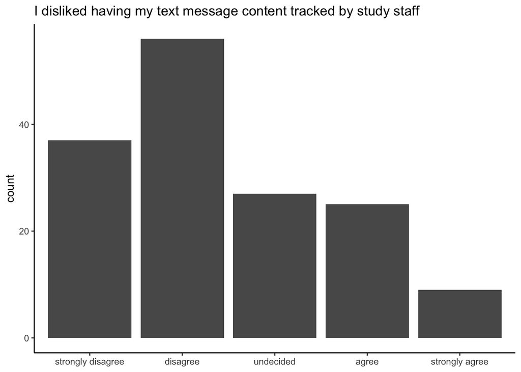

```r
burden_final %>%
  mutate(dislike = recode(sms_content_dislike,
                          "1" = "strongly disagree",
                          "2" = "disagree",
                          "3" = "undecided",
                          "4" = "agree",
                          "5" = "strongly agree")) %>%
  mutate(dislike = fct_relevel(factor(dislike,
                                      c("strongly disagree",
                                        "disagree",
                                        "undecided",
                                        "agree",
                                        "strongly agree")))) %>%
  drop_na(dislike) %>%
  ggplot(aes (x = dislike)) +
  geom_bar() +
  scale_x_discrete(drop = FALSE) +
  xlab(NULL) +
  ggtitle("I disliked having my text message content tracked by study staff") +
  theme_classic()
```

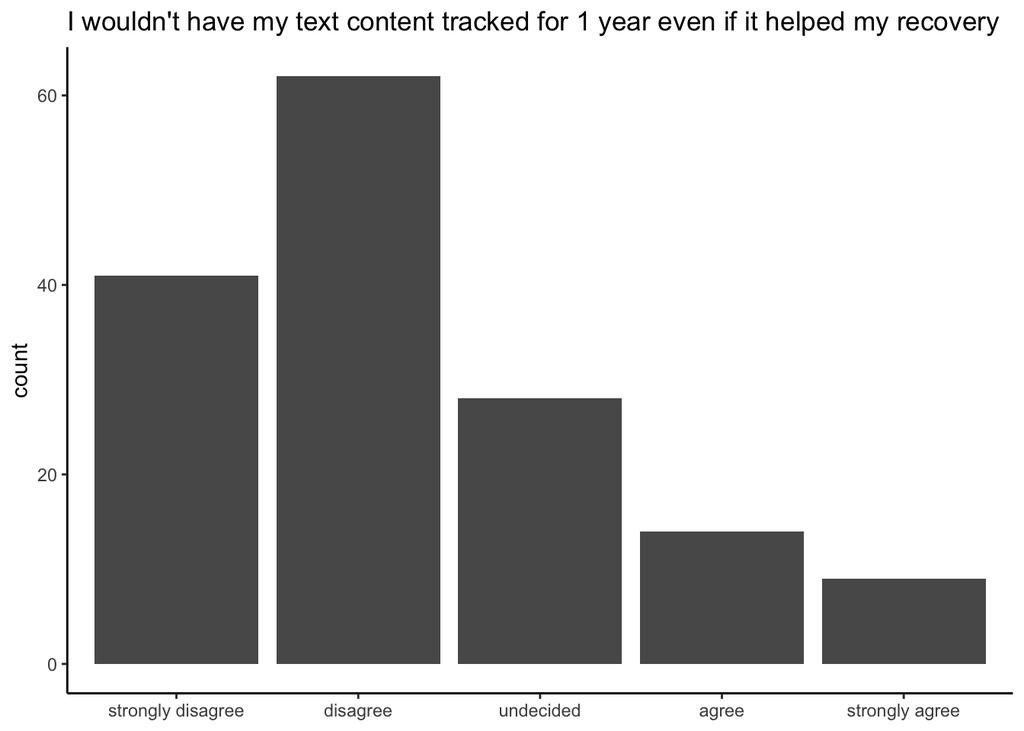

```r
burden_final %>%
  mutate(willing = recode(sms_content_1year,
                          "1" = "strongly disagree",
                          "2" = "disagree",
                          "3" = "undecided",
                          "4" = "agree",
                          "5" = "strongly agree")) %>%
  mutate(willing = fct_relevel(factor(willing,
                                      c("strongly disagree",
                                        "disagree",
                                        "undecided",
                                        "agree",
                                        "strongly agree")))) %>%
  drop_na(willing) %>%
  ggplot(aes (x = willing)) +
  geom_bar() +
  scale_x_discrete(drop = FALSE) +
  xlab(NULL) +
  ggtitle("I wouldn't have my text content tracked for 1 year even if it helped my recovery") +
  theme_classic()
```

Re: dislike of sms content being collected  
9 participants said they strongly agree.  
25 participants said they agree.

##### Call logs

Call logs burden measures (rbm_29 - rbm_30)

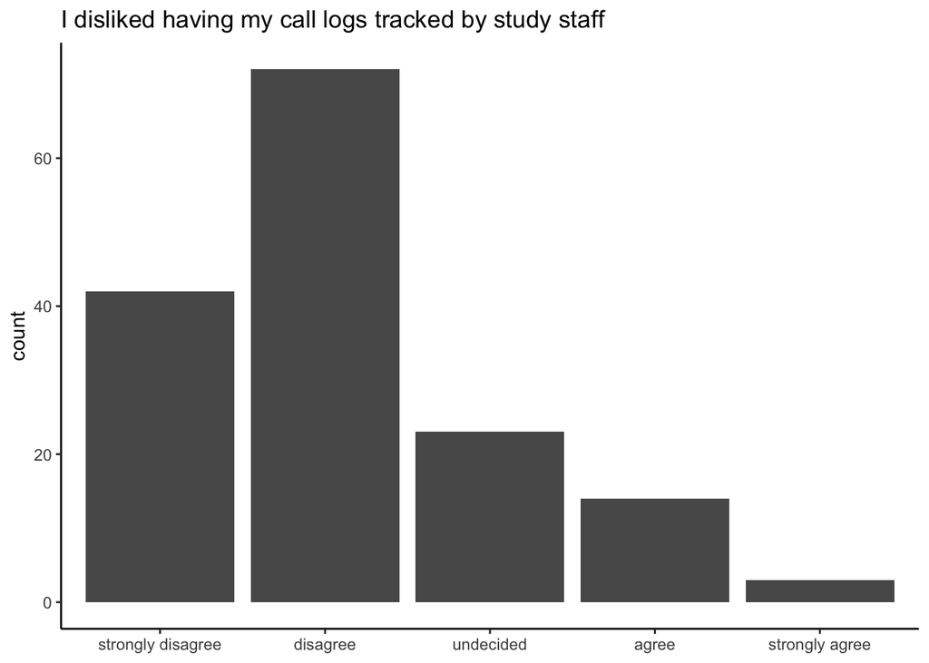

```r
burden_final %>%
  mutate(dislike = recode(phone_logs_dislike,
                          "1" = "strongly disagree",
                          "2" = "disagree",
                          "3" = "undecided",
                          "4" = "agree",
                          "5" = "strongly agree")) %>%
  mutate(dislike = fct_relevel(factor(dislike,
                                      c("strongly disagree",
                                        "disagree",
                                        "undecided",
                                        "agree",
                                        "strongly agree")))) %>%
  drop_na(dislike) %>%
  ggplot(aes (x = dislike)) +
  geom_bar() +
  scale_x_discrete(drop = FALSE) +
  xlab(NULL) +
  ggtitle("I disliked having my call logs tracked by study staff") +
  theme_classic()
```

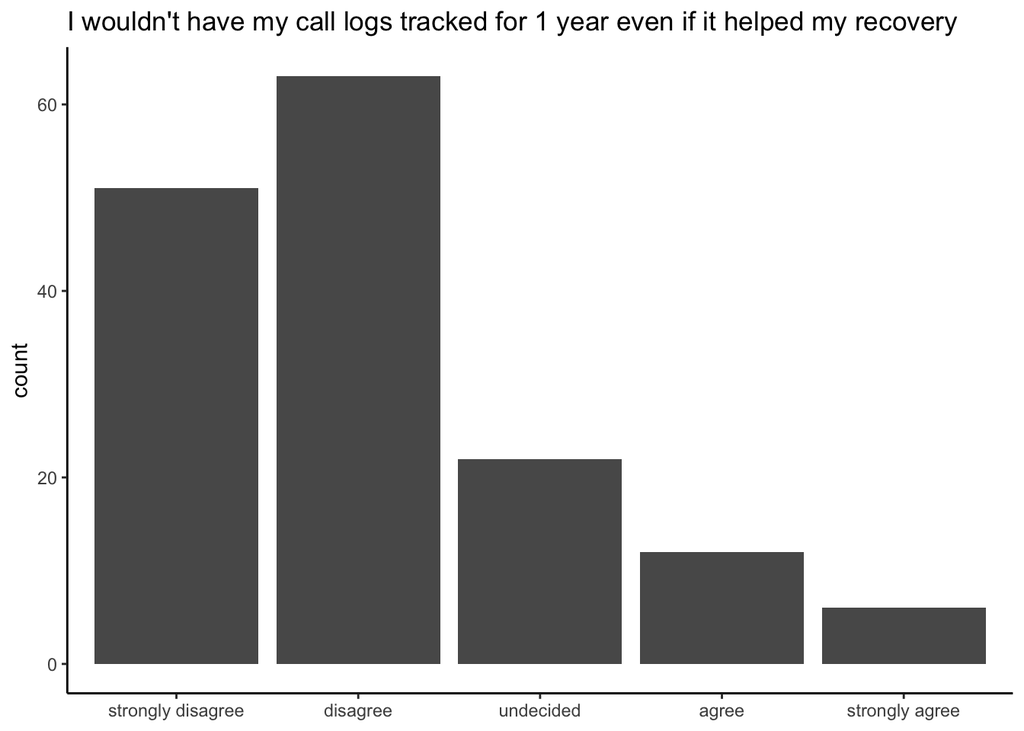

```r
burden_final %>%
  mutate(willing = recode(phone_logs_1year,
                          "1" = "strongly disagree",
                          "2" = "disagree",
                          "3" = "undecided",
                          "4" = "agree",
                          "5" = "strongly agree")) %>%
  mutate(willing = fct_relevel(factor(willing,
                                      c("strongly disagree",
                                        "disagree",
                                        "undecided",
                                        "agree",
                                        "strongly agree")))) %>%
  drop_na(willing) %>%
  ggplot(aes (x = willing)) +
  geom_bar() +
  scale_x_discrete(drop = FALSE) +
  xlab(NULL) +
  ggtitle("I wouldn't have my call logs tracked for 1 year even if it helped my recovery") +
  theme_classic()
```

Re: dislike of phone logs being collected  
3 participants said they strongly agree.  
14 participants said they agree.

Text comments on why people dislike the sms/phone logs or content monitored

```r
phone_dislike <- burden_final %>%
  filter_at(vars(sms_logs_dislike, sms_content_dislike, phone_logs_dislike),
            any_vars(. >=4)) %>%
  select(subid, phone_text)

phone_dislike %>%
  kable(caption =
        "Comments from participants who disliked phone info collected (strongly agree/agree)") %>%
  kable_styling(bootstrap_options = "striped", "condensed")  %>%
  scroll_box(width = "100%", height = "600px")
```

Comments from participants who disliked phone info collected (strongly agree/agree)

| subid | phone_text |
| --- | --- |
| 001 | I did not use the texting options and preferred using the phone calling options instead. |
| 005 | Never really understood what the study was going after with my log and what it meant to the survey and rexocefy |
| 016 | I have a lot of conversations that I don’t feel comfortable sharing with the staff. The call logs are not a big deal for me to be tracked but I feel as though access to text content can be intrusive. |
| 018 | Again, it freaks me out that you can know everything I say. I sometimes say sensitive things. |
| 023 | I would recommend emails as well |
| 034 | No comments |
| 038 | Generally didn’t matter except for occasional work or personal texts to my partnee |
| 039 | At first it is uncomfortable having to share messages documenting emotional immaturity and all the effed up co dependent relationships i have with some folks, but i focus on the study goal. It is much… |
| 043 | Big data |
| 047 | My only problem was having the text message content tracked because my girlfriend said she didn’t wanna to send me nudes because she knew the study people would see it |
| 054 | Just in general this feels intrusive but as part of the study it is fine! |
| 056 | It feels Invacive but I didn’t have any issues with it |
| 064 | Nuthing really |
| 066 | Positive |
| 076 | Accountability keeps me honest |
| 077 | I get a lot of unsolicited texts from advertisers and political campaigns. |
| 080 | NA |
| 085 | Again, total invasion of privacy. |
| 100 | I do not like people reading my messages |
| 103 | I see the reason for the tracking (pattern gathering and all that groovy stuff) but I, Christopher Robin, had identified those who are my friends and those who just want to party. It was painful but t… |
| 109 | Loss of privacy for the sake of sorberity, okay I’ll give in |
| 135 | Nope |
| 143 | It’s intrusive , but i understand the utility. |
| 167 | Not fond of it but if it helps than it makes sense |
| 169 | It’s a pretty personal thing but I understand the reasoning behind that |
| 179 | No comment |
| 181 | Pretty much same answer as previous. |
| 183 | I don’t text or call a lot |
| 196 | I didn’t mind this part of the study much. |
| 203 | Too personal |
| 222 | It didn’t really matter to me a lot, but it did feel somewhat invasive and extreme |
| 232 | As i said in previous comment, i trust no one tracking my information. Too much of our privacy and protection is lost already In today’s society. think if someone was really bad off and could not reco… |
| 241 | It seems this was more to aid with the study research than to help with my recovery. If i could see a way it would be prioritized to help me, i would be more willing to have them tracked longer. Becau… |
| 245 | It feels like an invasion of privacy. |
| 248 | If i felt desperate in my recovery i would probably agree and appreciate that long term but i don’t think it was necessary for me |
| 252 | It did glean a highly amusing story for my memoir, so there’s that. It is a huge invasion but my sobriety is paramount to my overall health. |
| 259 | It’s annoying to be tracked but if it helps |
| 263 | Didn’t mind |
| 268 | Hate the idea of someone reading my text messages. |

There were 39 unique participants that agreed or strongly agreed with the fact that they disliked some element of the text/call data collected.

Some of the comments suggest they did not mind the data being collected, yet they answered as disliking it on the scaled question.

People seem to be mostly concerned with the content of their text messages. Participants express confidence in the study, but curiosity of what exactly we are doing with the data. The majority of comments are neutral about study staff tracking phone/text data.

### Summary of All Measures (based on final time point)

```r
burden_final %>%
  ungroup() %>%
  select(-(contains("_text"))) %>%
  select(-c(subid, date_central)) %>%
  varDescribe(Detail = 1) %>%
  kable(caption =
        "Summary stats for each measure (1 = strongly disagree, 5 = strongly agree)") %>%
  kable_styling(bootstrap_options = c("striped", "condensed"))
```

Summary stats for each measure (1 = strongly disagree, 5 = strongly agree)

|  | n | mean | sd | min | max |
| --- | --- | --- | --- | --- | --- |
| utc* | 154 | 1.544547e+09 | 1.9398e+07 | 1496678162 | 1575567245 |
| sleep_interfere* | 78 | 1.590000e+00 | 8.7000e-01 | 1 | 5 |
| sleep_dislike* | 78 | 1.820000e+00 | 1.0700e+00 | 1 | 4 |
| sleep_use_1year* | 78 | 2.120000e+00 | 1.3000e+00 | 1 | 5 |
| daily_survey_interfere* | 154 | 2.100000e+00 | 1.0000e+00 | 1 | 5 |
| daily_survey_dislike* | 154 | 2.060000e+00 | 9.3000e-01 | 1 | 5 |
| daily_survey_complete4* | 154 | 2.380000e+00 | 1.2300e+00 | 1 | 5 |
| daily_survey_complete1* | 154 | 1.760000e+00 | 1.0600e+00 | 1 | 5 |
| voice_note_interfere* | 154 | 2.220000e+00 | 1.0700e+00 | 1 | 5 |
| voice_note_dislike* | 154 | 2.500000e+00 | 1.2800e+00 | 1 | 5 |
| voice_note_1year* | 154 | 2.290000e+00 | 1.3000e+00 | 1 | 5 |
| location_dislike* | 154 | 1.980000e+00 | 9.5000e-01 | 1 | 5 |
| location_1year* | 154 | 2.080000e+00 | 1.1900e+00 | 1 | 5 |
| sms_logs_dislike* | 154 | 2.110000e+00 | 1.0300e+00 | 1 | 5 |
| sms_logs_1year* | 154 | 2.280000e+00 | 1.2100e+00 | 1 | 5 |
| sms_content_dislike* | 154 | 2.440000e+00 | 1.1900e+00 | 1 | 5 |
| sms_content_1year* | 154 | 2.270000e+00 | 1.1300e+00 | 1 | 5 |
| phone_logs_dislike* | 154 | 2.120000e+00 | 9.8000e-01 | 1 | 5 |
| phone_logs_1year* | 154 | 2.080000e+00 | 1.0700e+00 | 1 | 5 |

### Descriptives Across Time

Create data frame of participants with 3 time points

```r
burden_time <- burden %>%
  group_by(subid) %>%
  mutate(n_obs = n()) %>%
  filter(n_obs == 3) %>%
  # create time variable
  arrange(date_central) %>%
  mutate(time = row_number()) %>%
  glimpse()
```

```
## Rows: 396
## Columns: 28
## Groups: subid [132]
## $ subid                  <chr> "001", "002", "003", "001", "002", "003",…
## $ utc                    <chr> "1490978317", "1492812248", "1493227629",…
## $ date_central           <date> 2017-03-31, 2017-04-21, 2017-04-26, 2017…
## $ sleep_interfere        <chr> "3", "1", "1", "2", "1", "1", "2", "1", "…
## $ sleep_dislike          <chr> "2", "1", "1", "2", "1", "1", "2", "1", "…
## $ sleep_use_1year        <chr> "2", "1", "1", "2", "1", "1", "2", "5", "…
## $ sleep_text             <chr> "I would like to know more about the bedd…
## $ daily_survey_interfere <chr> "2", "2", "1", "2", "2", "1", "2", "2", "…
## $ daily_survey_dislike   <chr> "2", "2", "1", "2", "3", "1", "2", "2", "…
## $ daily_survey_complete4 <chr> "2", "1", "1", "3", "1", "1", "2", "5", "…
## $ daily_survey_complete1 <chr> "2", "1", "1", "2", "1", "1", "2", "5", "…
## $ daily_survey_text      <chr> "The daily survey questions should be cha…
```

[output cut: 16 more lines]

132 participants had 3 burden survey time points, making up a total of 396 data points.

#### Sleep Monitor

Interference (1 = strongly disagree)

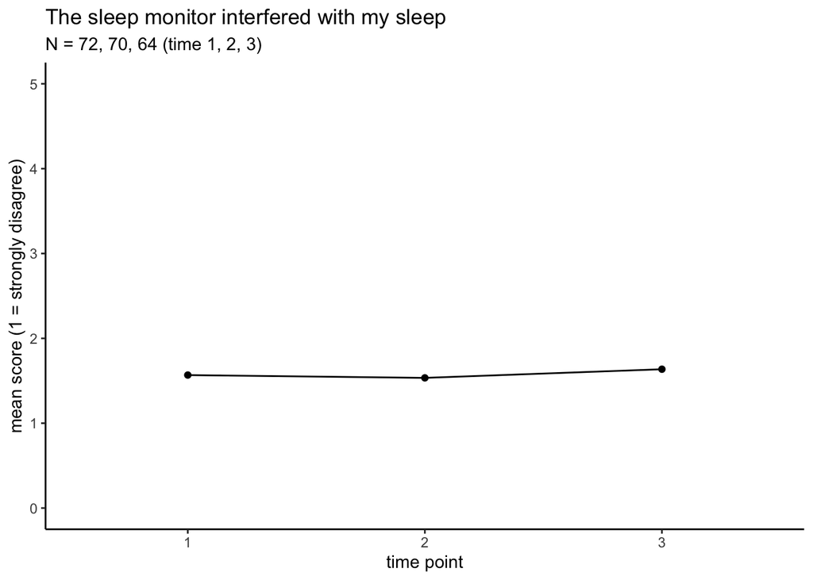

```r
burden_time %>%
  group_by(time) %>%
  summarise(mean_score = mean(as.numeric(sleep_interfere), na.rm = TRUE)) %>%
  ggplot(aes(x = time, y = mean_score)) +
  geom_point() +
  geom_line() +
  labs(title = "The sleep monitor interfered with my sleep",
       subtitle = "N = 72, 70, 64 (time 1, 2, 3)") +
  scale_x_discrete(name = "time point",
                   limits = c(1, 2, 3)) +
  scale_y_continuous(name = "mean score (1 = strongly disagree)",
                     limits = c(0, 5)) +
  theme_classic()
```

```r
varDescribeBy(as.numeric(burden_time$sleep_interfere), as.numeric(burden_time$time))
```

```
## IVList: 1
##    vars  n mean   sd median min max skew kurtosis
## X1    1 74 1.57 0.83      1   1   4 1.35        1
## --------------------------------------------------------
## IVList: 2
##    vars  n mean  sd median min max skew kurtosis
## X1    1 73 1.53 0.9      1   1   5 2.16      4.9
## --------------------------------------------------------
## IVList: 3
##    vars  n mean   sd median min max skew kurtosis
## X1    1 66 1.64 0.92      1   1   5 1.81     3.52
```

Dislike (1 = strongly disagree)

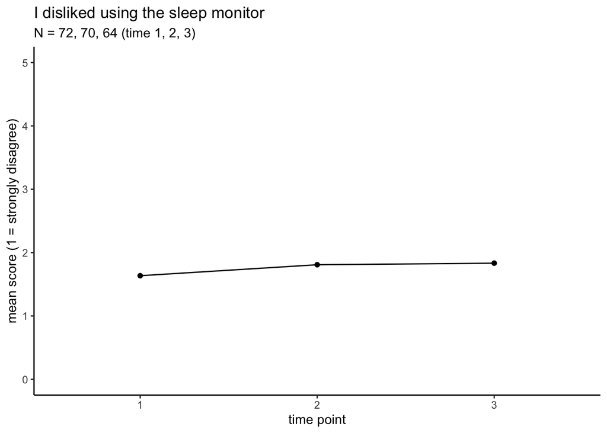

```r
burden_time %>%
  group_by(time) %>%
  summarise(mean_score = mean(as.numeric(sleep_dislike), na.rm = TRUE)) %>%
  ggplot(aes(x = time, y = mean_score)) +
  geom_point() +
  geom_line() +
  labs(title = "I disliked using the sleep monitor",
       subtitle = "N = 72, 70, 64 (time 1, 2, 3)") +
  scale_x_discrete(name = "time point",
                   limits = c(1, 2, 3)) +
  scale_y_continuous(name = "mean score (1 = strongly disagree)",
                     limits = c(0, 5)) +
  theme_classic()
```

```r
varDescribeBy(as.numeric(burden_time$sleep_dislike), as.numeric(burden_time$time))
```

```
## IVList: 1
##    vars  n mean   sd median min max skew kurtosis
## X1    1 74 1.64 0.88      1   1   5 1.47     1.98
## --------------------------------------------------------
## IVList: 2
##    vars  n mean   sd median min max skew kurtosis
## X1    1 73 1.81 1.06      1   1   5 1.34     0.99
## --------------------------------------------------------
## IVList: 3
##    vars  n mean   sd median min max skew kurtosis
## X1    1 66 1.83 1.05    1.5   1   4 1.04     -0.2
```

Would not use for 1 year to help recovery (1 = strongly disagree)

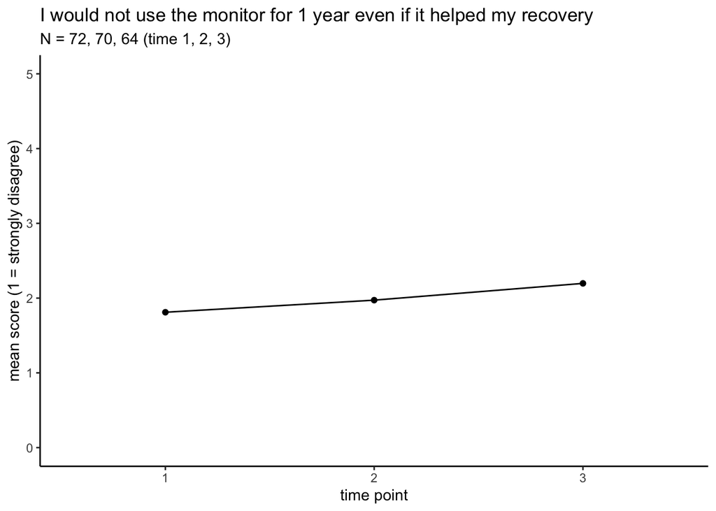

```r
burden_time %>%
  group_by(time) %>%
  summarise(mean_score = mean(as.numeric(sleep_use_1year), na.rm = TRUE)) %>%
  ggplot(aes(x = time, y = mean_score)) +
  geom_point() +
  geom_line() +
  labs(title = "I would not use the monitor for 1 year even if it helped my recovery",
       subtitle = "N = 72, 70, 64 (time 1, 2, 3)") +
  scale_x_discrete(name = "time point",
                   limits = c(1, 2, 3)) +
  scale_y_continuous(name = "mean score (1 = strongly disagree)",
                     limits = c(0, 5)) +
  theme_classic()
```

```r
varDescribeBy(as.numeric(burden_time$sleep_use_1year), as.numeric(burden_time$time))
```

```
## IVList: 1
##    vars  n mean  sd median min max skew kurtosis
## X1    1 74 1.81 1.2      1   1   5 1.53      1.4
## --------------------------------------------------------
## IVList: 2
##    vars  n mean   sd median min max skew kurtosis
## X1    1 73 1.97 1.27      2   1   5  1.3     0.57
## --------------------------------------------------------
## IVList: 3
##    vars  n mean   sd median min max skew kurtosis
## X1    1 66  2.2 1.34      2   1   5  0.9    -0.43
```

#### Daily Surveys

Interference (1 = strongly disagree)

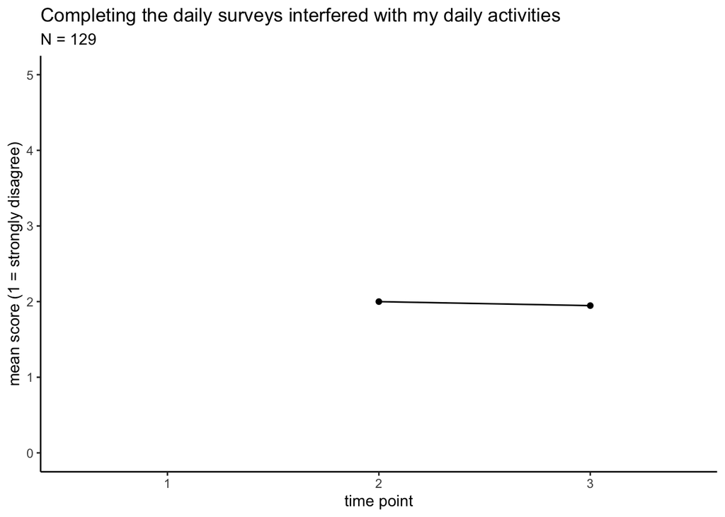

```r
burden_time %>%
  group_by(time) %>%
  summarise(mean_score = mean(as.numeric(daily_survey_interfere))) %>%
  ggplot(aes(x = time, y = mean_score)) +
  geom_point() +
  geom_line() +
  labs(title = "Completing the daily surveys interfered with my daily activities",
       subtitle = "N = 129") +
  scale_x_discrete(name = "time point",
                   limits = c(1, 2, 3)) +
  scale_y_continuous(name = "mean score (1 = strongly disagree)",
                     limits = c(0, 5)) +
  theme_classic()
```

```r
varDescribeBy(as.numeric(burden_time$daily_survey_interfere), as.numeric(burden_time$time))
```

```
## IVList: 1
##    vars   n mean   sd median min max skew kurtosis
## X1    1 131  1.9 0.85      2   1   5 1.31     2.28
## --------------------------------------------------------
## IVList: 2
##    vars   n mean   sd median min max skew kurtosis
## X1    1 132    2 1.01      2   1   5 1.05     0.58
## --------------------------------------------------------
## IVList: 3
##    vars   n mean   sd median min max skew kurtosis
## X1    1 132 1.95 0.87      2   1   5 1.42     2.66
```

Dislike (1 = strongly disagree)

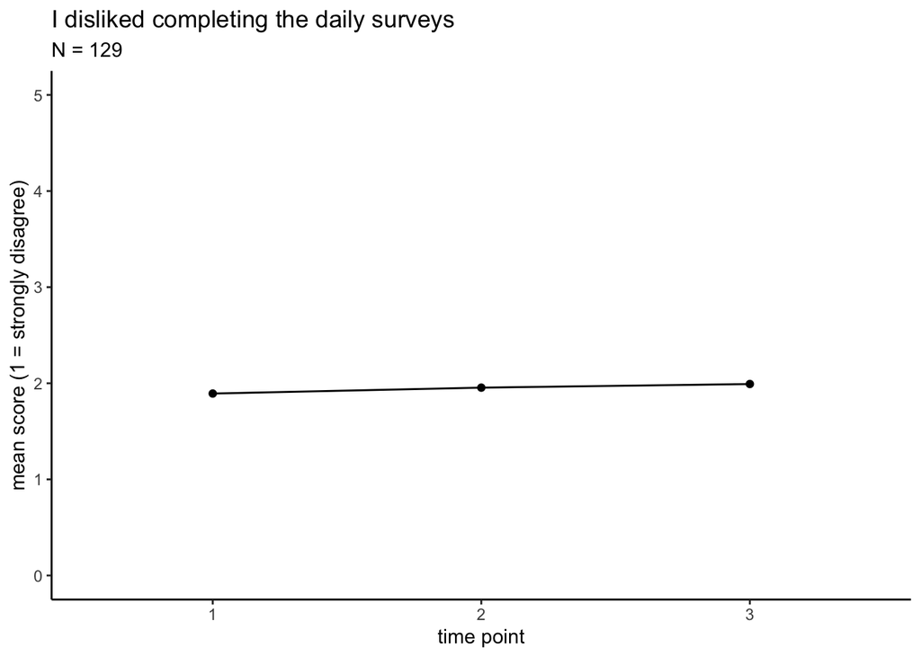

```r
burden_time %>%
  group_by(time) %>%
  summarise(mean_score = mean(as.numeric(daily_survey_dislike), na.rm = TRUE)) %>%
  ggplot(aes(x = time, y = mean_score)) +
  geom_point() +
  geom_line() +
  labs(title = "I disliked completing the daily surveys",
       subtitle = "N = 129") +
  scale_x_discrete(name = "time point",
                   limits = c(1, 2, 3)) +
  scale_y_continuous(name = "mean score (1 = strongly disagree)",
                     limits = c(0, 5)) +
  theme_classic()
```

```r
varDescribeBy(as.numeric(burden_time$daily_survey_dislike), as.numeric(burden_time$time))
```

```
## IVList: 1
##    vars   n mean   sd median min max skew kurtosis
## X1    1 131 1.89 0.86      2   1   5 1.06     1.12
## --------------------------------------------------------
## IVList: 2
##    vars   n mean   sd median min max skew kurtosis
## X1    1 132 1.95 0.92      2   1   5 1.07     0.99
## --------------------------------------------------------
## IVList: 3
##    vars   n mean  sd median min max skew kurtosis
## X1    1 132 1.99 0.9      2   1   5 0.94     0.56
```

Would not complete 4 daily for 1 year to help recovery (1 = strongly disagree)

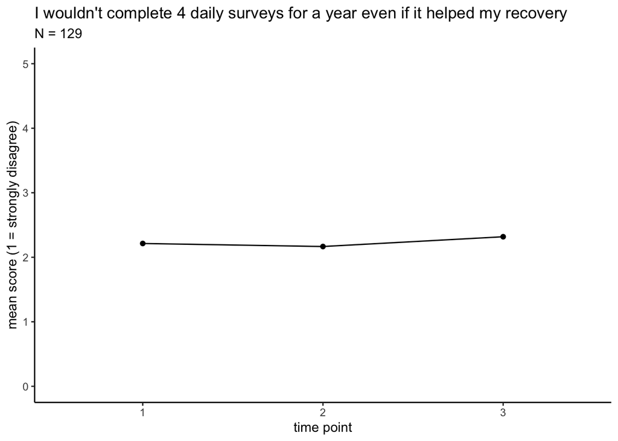

```r
burden_time %>%
  group_by(time) %>%
  summarise(mean_score = mean(as.numeric(daily_survey_complete4), na.rm = TRUE)) %>%
  ggplot(aes(x = time, y = mean_score)) +
  geom_point() +
  geom_line() +
  labs(title =
         "I wouldn't complete 4 daily surveys for a year even if it helped my recovery",
       subtitle = "N = 129") +
  scale_x_discrete(name = "time point",
                   limits = c(1, 2, 3)) +
  scale_y_continuous(name = "mean score (1 = strongly disagree)",
                     limits = c(0, 5)) +
  theme_classic()
```

```r
varDescribeBy(as.numeric(burden_time$daily_survey_complete4), as.numeric(burden_time$time))
```

```
## IVList: 1
##    vars   n mean   sd median min max skew kurtosis
## X1    1 131 2.21 1.18      2   1   5 0.71    -0.39
## --------------------------------------------------------
## IVList: 2
##    vars   n mean   sd median min max skew kurtosis
## X1    1 132 2.17 1.12      2   1   5 0.71    -0.43
## --------------------------------------------------------
## IVList: 3
##    vars   n mean   sd median min max skew kurtosis
## X1    1 132 2.32 1.19      2   1   5 0.68    -0.57
```

Would not complete 1 daily for 1 year to help recovery (1 = strongly disagree)

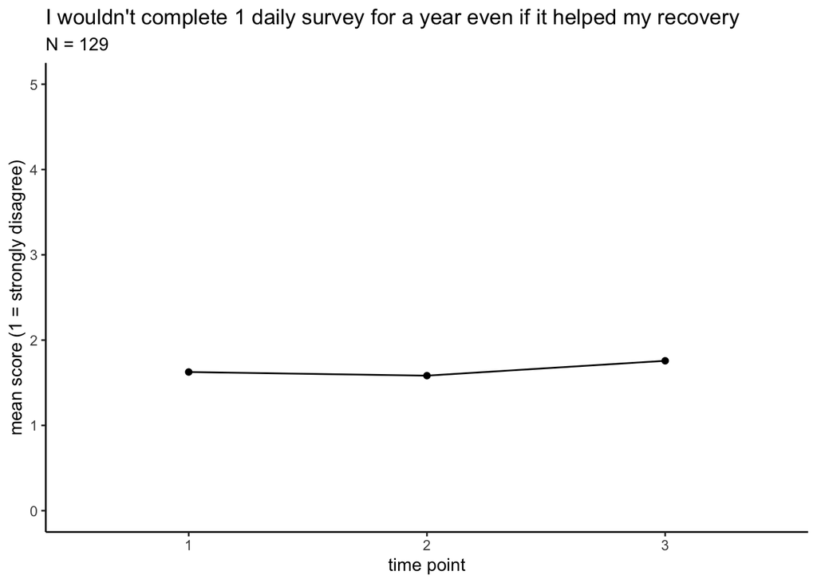

```r
burden_time %>%
  group_by(time) %>%
  summarise(mean_score = mean(as.numeric(daily_survey_complete1), na.rm = TRUE)) %>%
  ggplot(aes(x = time, y = mean_score)) +
  geom_point() +
  geom_line() +
  labs(title =
         "I wouldn't complete 1 daily survey for a year even if it helped my recovery",
       subtitle = "N = 129") +
  scale_x_discrete(name = "time point",
                   limits = c(1, 2, 3)) +
  scale_y_continuous(name = "mean score (1 = strongly disagree)",
                     limits = c(0, 5)) +
  theme_classic()
```

```r
varDescribeBy(as.numeric(burden_time$daily_survey_complete1), as.numeric(burden_time$time))
```

```
## IVList: 1
##    vars   n mean   sd median min max skew kurtosis
## X1    1 131 1.63 0.96      1   1   5 1.95     3.89
## --------------------------------------------------------
## IVList: 2
##    vars   n mean   sd median min max skew kurtosis
## X1    1 132 1.58 0.84      1   1   5 1.67     3.12
## --------------------------------------------------------
## IVList: 3
##    vars   n mean   sd median min max skew kurtosis
## X1    1 132 1.76 1.06      1   1   5 1.62     2.07
```

#### Voice Note Check-in

Interference (1 = strongly disagree)

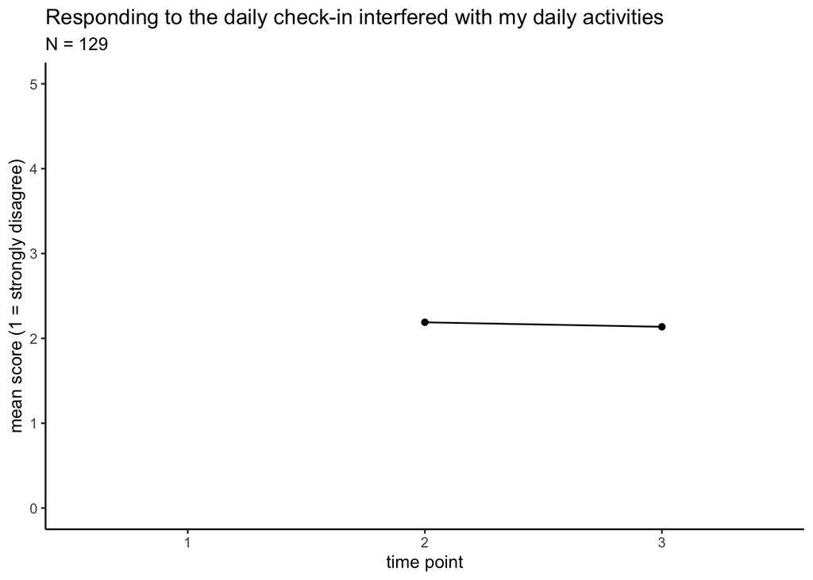

```r
burden_time %>%
  group_by(time) %>%
  summarise(mean_score = mean(as.numeric(voice_note_interfere))) %>%
  ggplot(aes(x = time, y = mean_score)) +
  geom_point() +
  geom_line() +
  labs(title = "Responding to the daily check-in interfered with my daily activities",
       subtitle = "N = 129") +
  scale_x_discrete(name = "time point",
                   limits = c(1, 2, 3)) +
  scale_y_continuous(name = "mean score (1 = strongly disagree)",
                     limits = c(0, 5)) +
  theme_classic()
```

```r
varDescribeBy(as.numeric(burden_time$voice_note_interfere), as.numeric(burden_time$time))
```

```
## IVList: 1
##    vars   n mean   sd median min max skew kurtosis
## X1    1 131 2.18 1.09      2   1   5 0.88     0.05
## --------------------------------------------------------
## IVList: 2
##    vars   n mean   sd median min max skew kurtosis
## X1    1 132 2.19 1.13      2   1   5 0.87    -0.07
## --------------------------------------------------------
## IVList: 3
##    vars   n mean   sd median min max skew kurtosis
## X1    1 132 2.14 1.03      2   1   5  0.8    -0.18
```

Dislike (1 = strongly disagree)

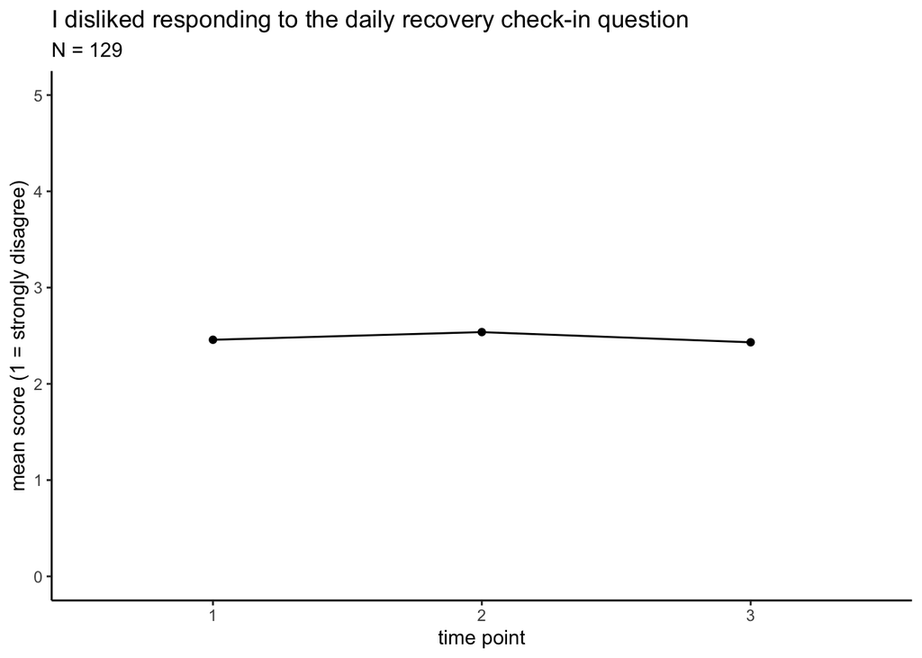

```r
burden_time %>%
  group_by(time) %>%
  summarise(mean_score = mean(as.numeric(voice_note_dislike), na.rm = TRUE)) %>%
  ggplot(aes(x = time, y = mean_score)) +
  geom_point() +
  geom_line() +
  labs(title = "I disliked responding to the daily recovery check-in question",
       subtitle = "N = 129") +
  scale_x_discrete(name = "time point",
                   limits = c(1, 2, 3)) +
  scale_y_continuous(name = "mean score (1 = strongly disagree)",
                     limits = c(0, 5)) +
  theme_classic()
```

```r
varDescribeBy(as.numeric(burden_time$voice_note_dislike), as.numeric(burden_time$time))
```

```
## IVList: 1
##    vars   n mean   sd median min max skew kurtosis
## X1    1 131 2.46 1.28      2   1   5 0.64    -0.68
## --------------------------------------------------------
## IVList: 2
##    vars   n mean   sd median min max skew kurtosis
## X1    1 132 2.54 1.23      2   1   5 0.61    -0.66
## --------------------------------------------------------
## IVList: 3
##    vars   n mean   sd median min max skew kurtosis
## X1    1 132 2.43 1.29      2   1   5 0.56    -0.89
```

Would not answer voice question for 1 year to help recovery (1 = strongly disagree)

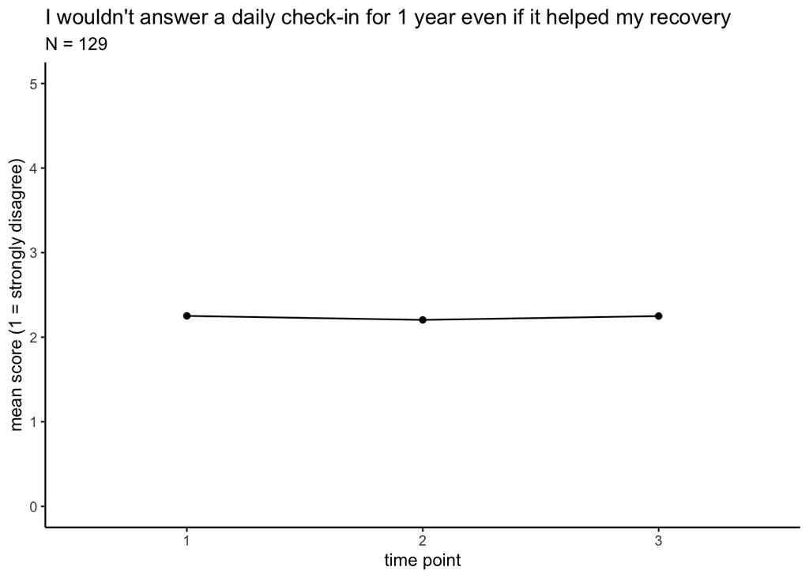

```r
burden_time %>%
  group_by(time) %>%
  summarise(mean_score = mean(as.numeric(voice_note_1year), na.rm = TRUE)) %>%
  ggplot(aes(x = time, y = mean_score)) +
  geom_point() +
  geom_line() +
  labs(title =
         "I wouldn't answer a daily check-in for 1 year even if it helped my recovery",
       subtitle = "N = 129") +
  scale_x_discrete(name = "time point",
                   limits = c(1, 2, 3)) +
  scale_y_continuous(name = "mean score (1 = strongly disagree)",
                     limits = c(0, 5)) +
  theme_classic()
```

```r
varDescribeBy(as.numeric(burden_time$voice_note_1year), as.numeric(burden_time$time))
```

```
## IVList: 1
##    vars   n mean   sd median min max skew kurtosis
## X1    1 131 2.25 1.25      2   1   5 0.81    -0.26
## --------------------------------------------------------
## IVList: 2
##    vars   n mean   sd median min max skew kurtosis
## X1    1 132  2.2 1.22      2   1   5 0.83    -0.22
## --------------------------------------------------------
## IVList: 3
##    vars   n mean   sd median min max skew kurtosis
## X1    1 132 2.25 1.27      2   1   5 0.87    -0.21
```

#### Location Tracking (GPS)

Dislike (1 = strongly disagree)

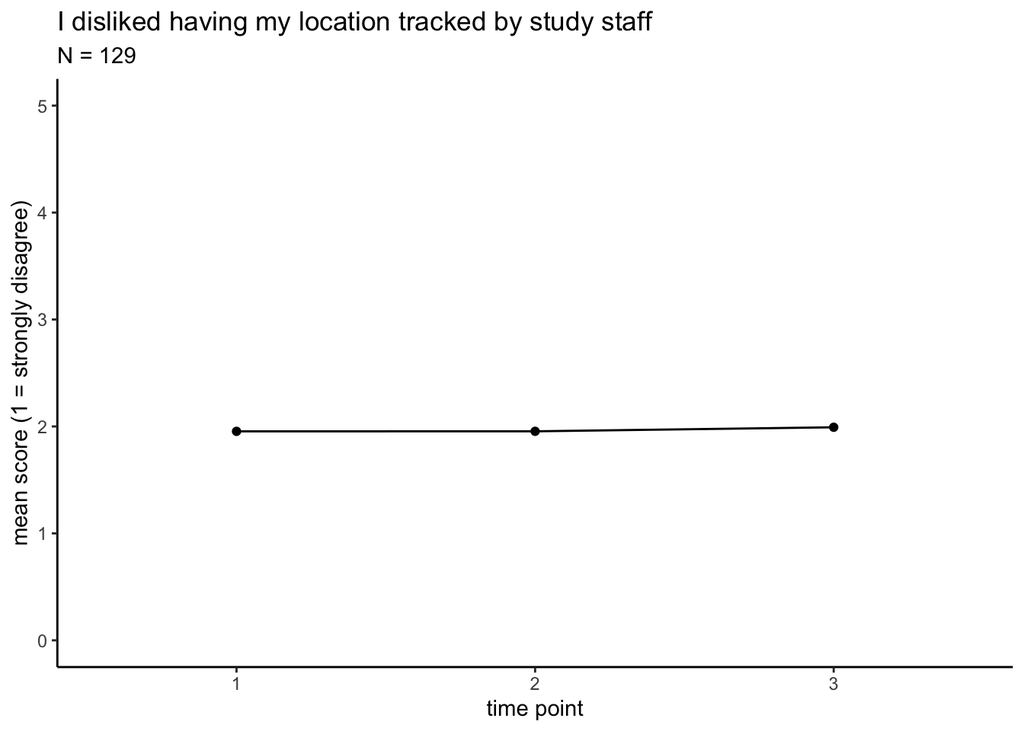

```r
burden_time %>%
  group_by(time) %>%
  summarise(mean_score = mean(as.numeric(location_dislike), na.rm = TRUE)) %>%
  ggplot(aes(x = time, y = mean_score)) +
  geom_point() +
  geom_line() +
  labs(title = "I disliked having my location tracked by study staff",
       subtitle = "N = 129") +
  scale_x_discrete(name = "time point",
                   limits = c(1, 2, 3)) +
  scale_y_continuous(name = "mean score (1 = strongly disagree)",
                     limits = c(0, 5)) +
  theme_classic()
```

```r
varDescribeBy(as.numeric(burden_time$location_dislike), as.numeric(burden_time$time))
```

```
## IVList: 1
##    vars   n mean   sd median min max skew kurtosis
## X1    1 131 1.95 0.94      2   1   5 0.69    -0.26
## --------------------------------------------------------
## IVList: 2
##    vars   n mean   sd median min max skew kurtosis
## X1    1 132 1.95 0.94      2   1   5 0.86     0.14
## --------------------------------------------------------
## IVList: 3
##    vars   n mean   sd median min max skew kurtosis
## X1    1 132 1.99 0.95      2   1   5  0.8    -0.01
```

Would not allow gps tracking for 1 year to help recovery (1 = strongly disagree)

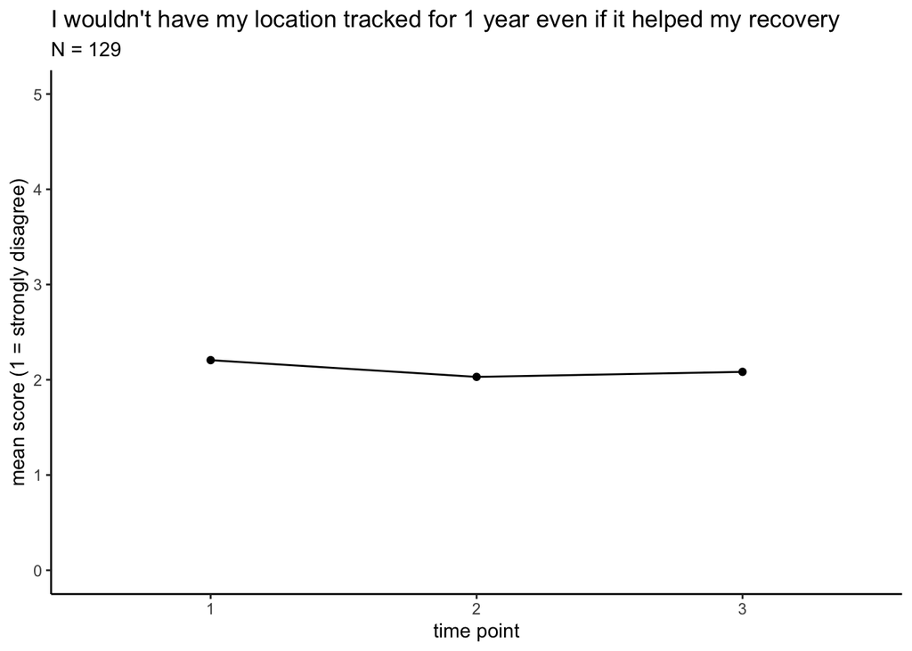

```r
burden_time %>%
  group_by(time) %>%
  summarise(mean_score = mean(as.numeric(location_1year), na.rm = TRUE)) %>%
  ggplot(aes(x = time, y = mean_score)) +
  geom_point() +
  geom_line() +
  labs(title =
         "I wouldn't have my location tracked for 1 year even if it helped my recovery",
       subtitle = "N = 129") +
  scale_x_discrete(name = "time point",
                   limits = c(1, 2, 3)) +
  scale_y_continuous(name = "mean score (1 = strongly disagree)",
                     limits = c(0, 5)) +
  theme_classic()
```

```r
varDescribeBy(as.numeric(burden_time$location_1year), as.numeric(burden_time$time))
```

```
## IVList: 1
##    vars   n mean   sd median min max skew kurtosis
## X1    1 131 2.21 1.26      2   1   5 0.93    -0.11
## --------------------------------------------------------
## IVList: 2
##    vars   n mean   sd median min max skew kurtosis
## X1    1 132 2.03 1.13      2   1   5 0.98     0.16
## --------------------------------------------------------
## IVList: 3
##    vars   n mean   sd median min max skew kurtosis
## X1    1 132 2.08 1.19      2   1   5 1.07     0.28
```

#### Phone Saving SMS and Call Log Information

##### SMS logs

Dislike (1 = strongly disagree)

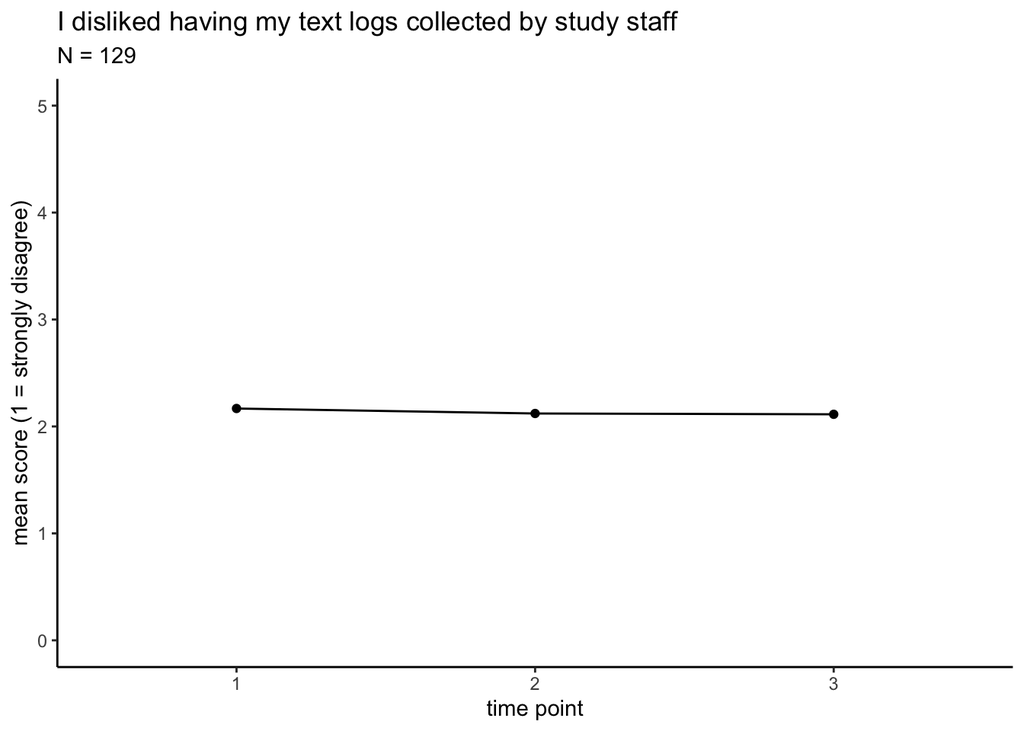

```r
burden_time %>%
  group_by(time) %>%
  summarise(mean_score = mean(as.numeric(sms_logs_dislike), na.rm = TRUE)) %>%
  ggplot(aes(x = time, y = mean_score)) +
  geom_point() +
  geom_line() +
  labs(title = "I disliked having my text logs collected by study staff",
       subtitle = "N = 129") +
  scale_x_discrete(name = "time point",
                   limits = c(1, 2, 3)) +
  scale_y_continuous(name = "mean score (1 = strongly disagree)",
                     limits = c(0, 5)) +
  theme_classic()
```

```r
varDescribeBy(as.numeric(burden_time$sms_logs_dislike), as.numeric(burden_time$time))
```

```
## IVList: 1
##    vars   n mean   sd median min max skew kurtosis
## X1    1 131 2.17 1.04      2   1   5 0.69    -0.22
## --------------------------------------------------------
## IVList: 2
##    vars   n mean   sd median min max skew kurtosis
## X1    1 132 2.12 0.95      2   1   5 0.56    -0.36
## --------------------------------------------------------
## IVList: 3
##    vars   n mean   sd median min max skew kurtosis
## X1    1 132 2.11 1.05      2   1   5 0.97     0.31
```

Would not allow text logs for 1 year to help recovery (1 = strongly disagree)

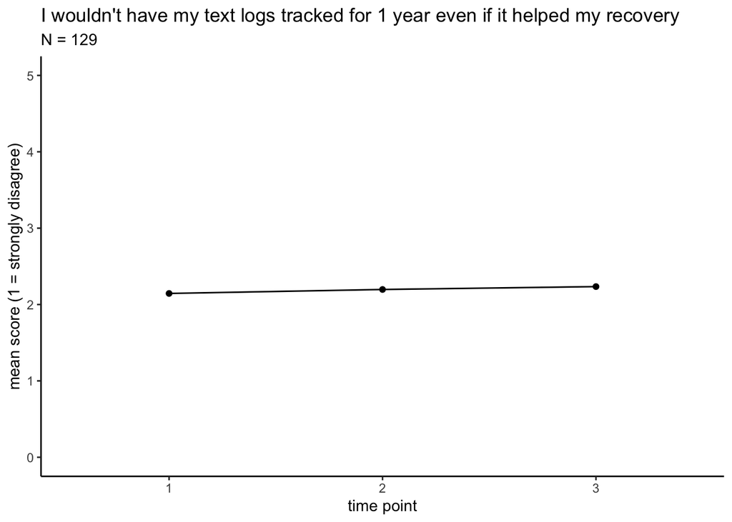

```r
burden_time %>%
  group_by(time) %>%
  summarise(mean_score = mean(as.numeric(sms_logs_1year), na.rm = TRUE)) %>%
  ggplot(aes(x = time, y = mean_score)) +
  geom_point() +
  geom_line() +
  labs(title =
         "I wouldn't have my text logs tracked for 1 year even if it helped my recovery",
       subtitle = "N = 129") +
  scale_x_discrete(name = "time point",
                   limits = c(1, 2, 3)) +
  scale_y_continuous(name = "mean score (1 = strongly disagree)",
                     limits = c(0, 5)) +
  theme_classic()
```

```r
varDescribeBy(as.numeric(burden_time$sms_logs_1year), as.numeric(burden_time$time))
```

```
## IVList: 1
##    vars   n mean   sd median min max skew kurtosis
## X1    1 131 2.15 1.08      2   1   5 0.89      0.3
## --------------------------------------------------------
## IVList: 2
##    vars   n mean   sd median min max skew kurtosis
## X1    1 132  2.2 1.14      2   1   5 0.82    -0.06
## --------------------------------------------------------
## IVList: 3
##    vars   n mean   sd median min max skew kurtosis
## X1    1 132 2.23 1.17      2   1   5  0.9    -0.02
```